# Reduplication study: GCA analysis and model comparisons - New Coding

Aitor San Jose, Mits Ota, Kenny Smith

13 September 2019

# 1 Preamble

These are GCA analyses and model comparisons run for the reduplication study. Originally in raw R script, now in R Notebook format. It saves tables as .doc files and plots as .pdf files. *This one uses the new coding of phonological repeition implemented by Kenny*.

# 2 Packages

```r
library(ggplot2)
library(broom)
library(lme4)
library(bbmle)
library(lmerTest)
library(sjPlot)
library(plyr)
library(reshape2)
```

# 3 Data preparation

## 3.1 Data read-in

This reads in the new dataset that includes the new coding of syllable and consonant repetition. But the script replaces the old equivalents (Adj_B, New_Redup_B) with the new variables (SyllableRepetition, ConsonantRepetition).

```r
df = read.table(file="data_june_2018_recoded2.csv", na.strings=c("", "NA"), sep=",", header=TRUE)
df = subset(df, select = -c(New_Redup_B, Adj_B))
colnames(df)[c(46, 47)] <- c("Adj_B", "New_Redup_B")
colnames(df)[6] <- "Unique_language"
df$Trial_Iteration[is.na(df$Trial_Iteration)] <- 0 #make NAs 0 for next line to work
df <-subset(df,Trial_Iteration != 1)  # keep seed languages and second round of iterations
# df <- subset(df, Transmitter == 1) # uncomment to keep only the data from the participants whose language was used to train the following generation
df_director<-subset(df,Stage!='interactM') # includes seed languages
df_matcher<-subset(df,Stage=='interactM') # includes only generations 1 to 5, since there is no accuracy for seed languages
df_director_generations_1_to_5 <- subset(df_director, Generation > 0) #excludes seed languages
```

## 3.2 Sum-coding

```r
contrasts(df_director$LexiconType) = contr.sum(2)
contrasts(df_director$GroupType) = contr.sum(2)
contrasts(df_matcher$LexiconType) = contr.sum(2)
contrasts(df_matcher$GroupType) = contr.sum(2)
```

## 3.3 Adding 3rd-order polynomials for GCA

```r
df_director$timebin = df_director$Generation + 1
t = poly(unique(df_director$timebin), 3)
df_director[,paste("ot", 1:3, sep="")] <- t[df_director$timebin, 1:3]
df_matcher$timebin = df_matcher$Generation
t = poly(unique(df_matcher$timebin), 3)
df_matcher[,paste("ot", 1:3, sep="")] <- t[df_matcher$timebin, 1:3]
```

# 4 The effect of repetition on learning (as measured by distance between seed words and first reproductions)

## 4.1 Calculation of edit distance

We calculate the edit distance between the training (seed) word and the typed word for the same object.

```r
df_learning = df_director
df_learning$Adj_V_B = ifelse(df_learning$Adj_V > 0, 1, 0)
SeedLabel = unique(ddply(df_learning[df_learning$Stage == "vocabTraining", ], c("GroupNumber", "GroupType", "LexiconType", "Meaning"), summarise, Seed = as.character(TrainingLabel), SeedRepC = as.integer(New_Redup_B)))
df_learning = merge(df_director_generations_1_to_5, SeedLabel, all.x = TRUE)
normdist <- function(x,y) {
  stringdist::stringdist(x,y,method="lv")/max(nchar(x),nchar(y))
}
df_learning$dist = mapply(normdist, as.character(df_learning$Seed), as.character(df_learning$TypedLabel))
df_learning$SeedLength = nchar(as.character(df_learning$Seed))
```

## 4.2 LME analysis of edit distance (by length, repetition and lexicon size)

This analysis looks at the edit distance between the seed words and the participants’ words in the first generation/round. The factors considered are: consonant repetition in the seed word (sSeedRepC), length of the seed word (sSeedLength) and lexicon size (LexiconType). sSeedRepC and sSeedLength are scaled. The strongest effect comes from the length of the seed word; shorter seed words are more faithfully reproduced than longer ones. But there is also an independent effect of (consonant) repetition; seed words that contains a repetition are more faithfullly reproduced than those without repetitions. Interestingly there is no effect of lexicon size, although there’s some indication of a three-way interaction between length x repetition x lexicon size.

```r
df_learning_first = subset(df_learning, Generation == 1)
df_learning_first$sSeedLength = scale(df_learning_first$SeedLength)
df_learning_first$sSeedRepC = scale(df_learning_first$SeedRepC)
learning_01 = lmer(dist ~ LexiconType*sSeedRepC*sSeedLength + (1|Unique_Participant) + (1|Meaning), data=df_learning_first, control=lmerControl(optimizer = "bobyqa", optCtrl=list(maxfun=1e5)), REML=FALSE)
summary(learning_01)
```

```
Linear mixed model fit by maximum likelihood . t-tests use Satterthwaite's
  method [lmerModLmerTest]
Formula:
dist ~ LexiconType * sSeedRepC * sSeedLength + (1 | Unique_Participant) +
    (1 | Meaning)
   Data: df_learning_first
Control: lmerControl(optimizer = "bobyqa", optCtrl = list(maxfun = 1e+05))

     AIC      BIC   logLik deviance df.resid
   321.1    371.4   -149.5    299.1      706

Scaled residuals:
    Min      1Q  Median      3Q     Max
-2.0804 -0.7050 -0.1771  0.6912  3.1854

Random effects:
 Groups             Name        Variance Std.Dev.
 Unique_Participant (Intercept) 0.024016 0.15497
 Meaning            (Intercept) 0.000109 0.01044
 Residual                       0.079215 0.28145
Number of obs: 717, groups:  Unique_Participant, 48; Meaning, 18

Fixed effects:
                                         Estimate Std. Error         df
(Intercept)                              0.362104   0.034722  45.938301
LexiconTypesmall                        -0.025637   0.049874  50.090843
sSeedRepC                               -0.029902   0.015032 693.700082
sSeedLength                              0.098228   0.013964 671.428017
LexiconTypesmall:sSeedRepC               0.021124   0.023293 689.390540
LexiconTypesmall:sSeedLength            -0.009428   0.022652 664.486123
sSeedRepC:sSeedLength                    0.011984   0.014396 629.963622
LexiconTypesmall:sSeedRepC:sSeedLength  -0.043605   0.024272 668.073718
                                       t value Pr(>|t|)
(Intercept)                             10.429 1.07e-13 ***
LexiconTypesmall                        -0.514   0.6095
sSeedRepC                               -1.989   0.0471 *
sSeedLength                              7.034 4.94e-12 ***
LexiconTypesmall:sSeedRepC               0.907   0.3648
LexiconTypesmall:sSeedLength            -0.416   0.6774
sSeedRepC:sSeedLength                    0.832   0.4055
LexiconTypesmall:sSeedRepC:sSeedLength  -1.797   0.0729 .
---
Signif. codes:  0 ‘***’ 0.001 ‘**’ 0.01 ‘*’ 0.05 ‘.’ 0.1 ‘ ’ 1

Correlation of Fixed Effects:
            (Intr) LxcnTy sSdRpC sSdLng LxT:SRC LxT:SL sSRC:S
LxcnTypsmll -0.693
sSeedRepC    0.013 -0.009
sSeedLength -0.016  0.012 -0.269
LxcnTyp:SRC -0.008  0.024 -0.645  0.173
LxcnTyps:SL  0.010  0.001  0.165 -0.616 -0.198
sSdRpC:sSdL -0.106  0.074 -0.243  0.035  0.156  -0.021
LxcT:SRC:SL  0.063 -0.087  0.144 -0.020 -0.145   0.110 -0.593
```

## 4.3 Plot showing the effects of repetition in (and length of) the seed word

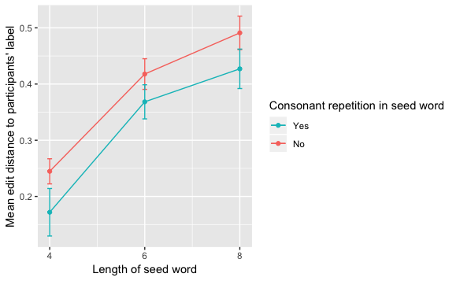

```r
RepAgg = ddply(df_learning_first, c("SeedLength", "SeedRepC"), summarise, mean=mean(dist), sd=sd(dist), n=length(dist))
RepAgg$se = RepAgg$sd/sqrt(RepAgg$n)
RepAgg$SeedRepC = as.factor(RepAgg$SeedRepC)
ggplot(RepAgg, aes(x=SeedLength, y=mean, colour=SeedRepC), group=SeedRepC) +
    geom_errorbar(aes(ymin=mean-se, ymax=mean+se), width=.1) +
    geom_line() +
    scale_x_continuous(breaks = c(4, 6, 8)) +
    geom_point() +
    xlab("Length of seed word") +
    ylab("Mean edit distance to participants' label") +
    scale_colour_discrete(name="Consonant repetition in seed word", breaks = c("1", "0"), labels=c("Yes", "No"))
```

## 4.4 Exploration of drift from seed words

This plot shows what happens after the first generation/round. There apears to be a shift away from the seed words around Gen 2-3 for the chains, which corresponds to the increase in the repetition in their labels.

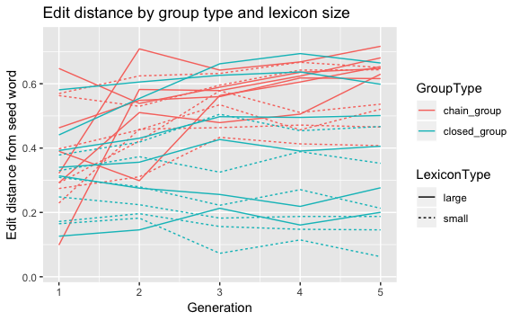

```r
groups = ddply(df_director, c("GroupType", "LexiconType", "GroupNumber"), summarise, n=length(Block))
groups$group_id = factor(LETTERS[1:24])
df_learning_plot = merge(df_learning, groups, all.x = TRUE)
ggplot(df_learning_plot, aes(Generation, dist, group = group_id, colour=GroupType, linetype=LexiconType)) +
  stat_summary(fun.data=mean_se, geom="line") +
  ylab("Edit distance from seed word")+
  ggtitle('Edit distance by group type and lexicon size')
```

```r
dev.print(pdf, 'Edit distance by group type - dog dinner.pdf')
```

# 5 The effect of repetition on communication (as measured by accuracy in Gen1)

## 5.1 Analysis

```r
Instruct = ddply(df_director[df_director$Generation > 0, ], c("Unique_language", "Block", "Meaning"), summarise, DirLabel = TypedLabel, DirRep = New_Redup_B)
df_inst_match= merge(df_matcher, Instruct, all.x = TRUE)
df_inst_match$DirLength = nchar(as.character(df_inst_match$DirLabel))
df_inst_match$sDirLength = scale(df_inst_match$DirLength)
RepScore1 = glmer(Score ~ LexiconType*DirRep*sDirLength + (1|Unique_Participant) + (1|Meaning), data = df_inst_match[df_inst_match$Generation ==1, ], family=binomial, control=glmerControl(optimizer = "bobyqa", optCtrl=list(maxfun=1e5)))
```

```
singular fit
```

```r
summary(RepScore1)
```

```
Generalized linear mixed model fit by maximum likelihood (Laplace
  Approximation) [glmerMod]
 Family: binomial  ( logit )
Formula:
Score ~ LexiconType * DirRep * sDirLength + (1 | Unique_Participant) +
    (1 | Meaning)
   Data: df_inst_match[df_inst_match$Generation == 1, ]
Control: glmerControl(optimizer = "bobyqa", optCtrl = list(maxfun = 1e+05))

     AIC      BIC   logLik deviance df.resid
   921.4    967.1   -450.7    901.4      704

Scaled residuals:
    Min      1Q  Median      3Q     Max
-2.6162 -0.9107  0.4689  0.7394  1.7934

Random effects:
 Groups             Name        Variance Std.Dev.
 Unique_Participant (Intercept) 0.4574   0.6763
 Meaning            (Intercept) 0.0000   0.0000
Number of obs: 714, groups:  Unique_Participant, 48; Meaning, 18

Fixed effects:
                               Estimate Std. Error z value Pr(>|z|)
(Intercept)                     0.47085    0.14396   3.271  0.00107 **
LexiconType1                   -0.12172    0.14364  -0.847  0.39676
DirRep                         -0.17039    0.19793  -0.861  0.38930
sDirLength                     -0.55506    0.10847  -5.117  3.1e-07 ***
LexiconType1:DirRep            -0.02975    0.19806  -0.150  0.88060
LexiconType1:sDirLength         0.25175    0.10793   2.333  0.01967 *
DirRep:sDirLength               0.33261    0.20013   1.662  0.09651 .
LexiconType1:DirRep:sDirLength -0.26156    0.20016  -1.307  0.19129
---
Signif. codes:  0 ‘***’ 0.001 ‘**’ 0.01 ‘*’ 0.05 ‘.’ 0.1 ‘ ’ 1

Correlation of Fixed Effects:
            (Intr) LxcnT1 DirRep sDrLng LxT1:DR LT1:DL DrR:DL
LexiconTyp1 -0.101
DirRep      -0.411  0.072
sDirLength   0.071  0.044 -0.067
LxcnTyp1:DR  0.069 -0.412 -0.257 -0.026
LxcnTyp1:DL  0.046  0.079 -0.030 -0.137 -0.068
DrRp:sDrLng -0.050 -0.020 -0.172 -0.545  0.095   0.072
LxcT1:DR:DL -0.022 -0.052  0.096  0.074 -0.171  -0.546 -0.234
convergence code: 0
singular fit
```

## 5.2 Plot

Here’s a plot showing the effects of the length of the director’s word and lexicon size. Because there were very few director words with odd numbers of segments or with segments below 4, length was collapsed into 3 categories. It can be seen from this that those communicating the small lexicon are more accurate than those with the large lexicon, but this effect disappears when the words get long.

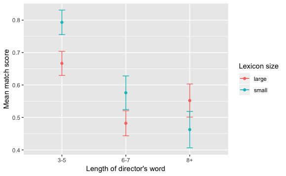

```r
df_inst_match$DirLengthCat[df_inst_match$DirLength >= 8] <- "8+"
df_inst_match$DirLengthCat[df_inst_match$DirLength >= 6 & df_inst_match$DirLength < 8] <- "6-7"
df_inst_match$DirLengthCat[df_inst_match$DirLength < 6] <- "3-5"
Gen1ComAgg = ddply(df_inst_match[df_inst_match$Generation == 1, ], c("LexiconType", "DirLengthCat"), summarise, mean=mean(Score), sd=sd(Score), n=length(Score))
Gen1ComAgg$se = Gen1ComAgg$sd/sqrt(Gen1ComAgg$n)
Gen1ComAgg=Gen1ComAgg[complete.cases(Gen1ComAgg), ]
ggplot(Gen1ComAgg, aes(x=DirLengthCat, y=mean, colour=LexiconType), group=LexiconType) +
    geom_errorbar(aes(ymin=mean-se, ymax=mean+se), width=.1) +
    geom_line() +
    geom_point() +
    xlab("Length of director's word") +
    ylab("Mean match score") +
    scale_colour_discrete(name="Lexicon size")
```

# 6 Analysis of consonant repetition (“CVC”)

## 6.1 CVC: Descriptive plot

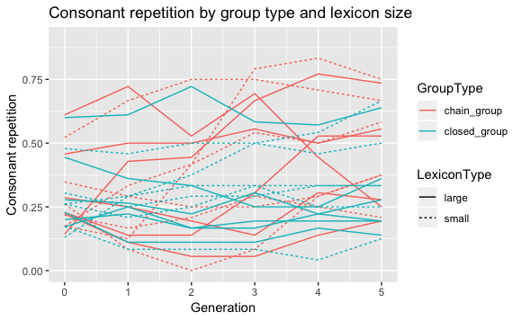

```r
groups = ddply(df_director, c("GroupType", "LexiconType", "GroupNumber"), summarise, n=length(Block))
groups$group_id = factor(LETTERS[1:24])
df_director_plot = merge(df_director, groups, all.x = TRUE)
ggplot(df_director_plot, aes(Generation, New_Redup_B, group = group_id, colour=GroupType, linetype=LexiconType)) +
  stat_summary(fun.data=mean_se, geom="line") +
  ylab("Consonant repetition")+
  ggtitle('Consonant repetition by group type and lexicon size')
```

```r
dev.print(pdf, 'Consonant repetition by group type - dog dinner.pdf')
```

## 6.2 CVC: Full models

```r
# CVC_third_order <- glmer(New_Redup_B ~ #maximal random effect structure, up to cubic term
#                 (ot1+ot2+ot3) * GroupType * LexiconType + (1+ot1+ot2+ot3|Unique_Participant) +
#                 (1+ot1+ot2+ot3 |Meaning) + (1+ot1+ot2+ot3|Pair), data=df_director, family=binomial,
#                 control=glmerControl(optimizer = "bobyqa", optCtrl=list(maxfun=1e5)))
#CVC_second_order <- glmer(New_Redup_B ~ #maximal random effect structure, up to quadratic term
#                 (ot1+ot2) * GroupType * LexiconType + (1+ot1+ot2|Unique_Participant) +
#                 (1+ot1+ot2 |Meaning) + (1+ot1+ot2|Pair), data=df_director, family=binomial,
#                 control=glmerControl(optimizer = "bobyqa", optCtrl=list(maxfun=1e5)))
#CVC_first_order <- glmer(New_Redup_B ~ #maximal random effect structure, up to linear term
#                 ot1 * GroupType * LexiconType + (1+ot1|Unique_Participant) + (1+ot1 |Meaning) +
#                 (1+ot1+ot2|Pair), data=df_director, family=binomial,
#                 control=glmerControl(optimizer = "bobyqa", optCtrl=list(maxfun=1e5)))
```

## 6.3 CVC: Reduced models

The full models above all result in singular fit. The models converge without singular fit when all the random slopes are removed and ‘Pair’ is also removed as a random effect.Below are models with these terms dropped.

```r
CVC_third_order <- glmer(New_Redup_B ~ #maximal random effect structure, up to cubic term
                  (ot1+ot2+ot3) * GroupType * LexiconType + (1|Unique_Participant) + (1|Meaning),
                  data=df_director, family=binomial,
                  control=glmerControl(optimizer = "bobyqa", optCtrl=list(maxfun=1e5)))
CVC_second_order <- glmer(New_Redup_B ~ #maximal random effect structure, up to quadratic term
                    (ot1+ot2) * GroupType * LexiconType + (1|Unique_Participant) + (1|Meaning),
                   data=df_director, family=binomial,
                   control=glmerControl(optimizer = "bobyqa", optCtrl=list(maxfun=1e5)))
CVC_first_order <- glmer(New_Redup_B ~ #maximal random effect structure, up to linear term
                    ot1 * GroupType * LexiconType + (1|Unique_Participant) + (1|Meaning),
                    data=df_director, family=binomial,
                    control=glmerControl(optimizer = "bobyqa", optCtrl=list(maxfun=1e5)))
summary(CVC_third_order)
```

```
Generalized linear mixed model fit by maximum likelihood (Laplace
  Approximation) [glmerMod]
 Family: binomial  ( logit )
Formula: New_Redup_B ~ (ot1 + ot2 + ot3) * GroupType * LexiconType + (1 |
    Unique_Participant) + (1 | Meaning)
   Data: df_director
Control: glmerControl(optimizer = "bobyqa", optCtrl = list(maxfun = 1e+05))

     AIC      BIC   logLik deviance df.resid
  5012.0   5126.5  -2488.0   4976.0     4275

Scaled residuals:
    Min      1Q  Median      3Q     Max
-1.9153 -0.6408 -0.4376  0.8083  5.0050

Random effects:
 Groups             Name        Variance Std.Dev.
 Unique_Participant (Intercept) 0.8121   0.9012
 Meaning            (Intercept) 0.2797   0.5289
Number of obs: 4293, groups:  Unique_Participant, 156; Meaning, 18

Fixed effects:
                             Estimate Std. Error z value Pr(>|z|)
(Intercept)                 -0.797421   0.161469  -4.939 7.87e-07 ***
ot1                          0.488495   0.187113   2.611  0.00904 **
ot2                          0.060052   0.178632   0.336  0.73674
ot3                         -0.111754   0.153346  -0.729  0.46614
GroupType1                   0.182995   0.089418   2.047  0.04071 *
LexiconType1                -0.023338   0.102203  -0.228  0.81938
ot1:GroupType1               0.319587   0.126504   2.526  0.01153 *
ot2:GroupType1              -0.024023   0.126953  -0.189  0.84992
ot3:GroupType1              -0.149515   0.127569  -1.172  0.24118
ot1:LexiconType1            -0.325435   0.187024  -1.740  0.08185 .
ot2:LexiconType1             0.105347   0.178676   0.590  0.55546
ot3:LexiconType1             0.043746   0.153343   0.285  0.77543
GroupType1:LexiconType1      0.018755   0.089352   0.210  0.83374
ot1:GroupType1:LexiconType1  0.017291   0.126475   0.137  0.89126
ot2:GroupType1:LexiconType1 -0.031397   0.126867  -0.247  0.80454
ot3:GroupType1:LexiconType1  0.007978   0.127512   0.063  0.95011
---
Signif. codes:  0 ‘***’ 0.001 ‘**’ 0.01 ‘*’ 0.05 ‘.’ 0.1 ‘ ’ 1
```

```
Correlation matrix not shown by default, as p = 16 > 12.
Use print(x, correlation=TRUE)  or
    vcov(x)        if you need it
```

```r
summary(CVC_second_order)
```

```
Generalized linear mixed model fit by maximum likelihood (Laplace
  Approximation) [glmerMod]
 Family: binomial  ( logit )
Formula:
New_Redup_B ~ (ot1 + ot2) * GroupType * LexiconType + (1 | Unique_Participant) +
    (1 | Meaning)
   Data: df_director
Control: glmerControl(optimizer = "bobyqa", optCtrl = list(maxfun = 1e+05))

     AIC      BIC   logLik deviance df.resid
  5005.5   5094.6  -2488.8   4977.5     4279

Scaled residuals:
    Min      1Q  Median      3Q     Max
-1.9033 -0.6434 -0.4386  0.8047  5.0822

Random effects:
 Groups             Name        Variance Std.Dev.
 Unique_Participant (Intercept) 0.8187   0.9048
 Meaning            (Intercept) 0.2798   0.5289
Number of obs: 4293, groups:  Unique_Participant, 156; Meaning, 18

Fixed effects:
                            Estimate Std. Error z value Pr(>|z|)
(Intercept)                 -0.81723    0.16091  -5.079  3.8e-07 ***
ot1                          0.49050    0.16355   2.999  0.00271 **
ot2                          0.05608    0.15746   0.356  0.72173
GroupType1                   0.20507    0.08470   2.421  0.01547 *
LexiconType1                -0.02359    0.10120  -0.233  0.81569
ot1:GroupType1               0.31018    0.12513   2.479  0.01318 *
ot2:GroupType1              -0.01850    0.12584  -0.147  0.88315
ot1:LexiconType1            -0.35122    0.16361  -2.147  0.03182 *
ot2:LexiconType1             0.13020    0.15746   0.827  0.40829
GroupType1:LexiconType1      0.02428    0.08469   0.287  0.77433
ot1:GroupType1:LexiconType1  0.02287    0.12510   0.183  0.85494
ot2:GroupType1:LexiconType1 -0.03474    0.12575  -0.276  0.78233
---
Signif. codes:  0 ‘***’ 0.001 ‘**’ 0.01 ‘*’ 0.05 ‘.’ 0.1 ‘ ’ 1

Correlation of Fixed Effects:
```

[output cut: 9 more lines]

```
GrpTyp1:LT1  0.003  0.021 -0.018 -0.052 -0.504  0.008  -0.005   0.000 -0.005
ot1:GT1:LT1  0.000  0.003 -0.007  0.008 -0.281 -0.097   0.016   0.258  0.140
ot2:GT1:LT1  0.002 -0.005 -0.003 -0.005  0.246  0.016  -0.090   0.133  0.298
            GT1:LT o1:GT1:
ot1
ot2
GroupType1
LexiconTyp1
ot1:GrpTyp1
ot2:GrpTyp1
ot1:LxcnTy1
ot2:LxcnTy1
GrpTyp1:LT1
ot1:GT1:LT1  0.416
ot2:GT1:LT1 -0.389  0.023
```

```r
summary(CVC_first_order)
```

```
Generalized linear mixed model fit by maximum likelihood (Laplace
  Approximation) [glmerMod]
 Family: binomial  ( logit )
Formula:
New_Redup_B ~ ot1 * GroupType * LexiconType + (1 | Unique_Participant) +
    (1 | Meaning)
   Data: df_director
Control: glmerControl(optimizer = "bobyqa", optCtrl = list(maxfun = 1e+05))

     AIC      BIC   logLik deviance df.resid
  4998.8   5062.5  -2489.4   4978.8     4283

Scaled residuals:
    Min      1Q  Median      3Q     Max
-1.9083 -0.6427 -0.4412  0.8085  5.0362

Random effects:
 Groups             Name        Variance Std.Dev.
 Unique_Participant (Intercept) 0.8181   0.9045
 Meaning            (Intercept) 0.2796   0.5288
Number of obs: 4293, groups:  Unique_Participant, 156; Meaning, 18

Fixed effects:
                             Estimate Std. Error z value Pr(>|z|)
(Intercept)                 -0.814661   0.158876  -5.128 2.93e-07 ***
ot1                          0.524337   0.145977   3.592 0.000328 ***
GroupType1                   0.194888   0.077314   2.521 0.011711 *
LexiconType1                -0.020530   0.097939  -0.210 0.833964
ot1:GroupType1               0.304013   0.123888   2.454 0.014130 *
ot1:LexiconType1            -0.277303   0.145879  -1.901 0.057313 .
GroupType1:LexiconType1      0.005124   0.077317   0.066 0.947161
ot1:GroupType1:LexiconType1  0.007622   0.123872   0.062 0.950938
---
Signif. codes:  0 ‘***’ 0.001 ‘**’ 0.01 ‘*’ 0.05 ‘.’ 0.1 ‘ ’ 1

Correlation of Fixed Effects:
            (Intr) ot1    GrpTy1 LxcnT1 ot1:GT1 o1:LT1 GT1:LT
ot1         -0.108
GroupType1  -0.288  0.125
LexiconTyp1 -0.038  0.001  0.018
ot1:GrpTyp1 -0.189  0.355  0.454 -0.005
ot1:LxcnTy1  0.001 -0.095  0.024 -0.172 -0.008
GrpTyp1:LT1  0.012  0.024 -0.080 -0.466  0.018   0.125
ot1:GT1:LT1 -0.003 -0.008  0.018 -0.306 -0.095   0.355  0.454
```

## 6.4 CVC: Model comparison

```r
CVC_model.names <- c("CVC first order","CVC second order","CVC third order")
CVC_summ.table <- do.call(rbind, lapply(list(CVC_first_order,CVC_second_order,CVC_third_order), broom::glance))
CVC_table.cols <- c("df.residual", "deviance", "AIC")
CVC_reported.table <- CVC_summ.table[CVC_table.cols]
names(CVC_reported.table) <- c("Resid.Df", "Resid.Dev", "AIC")
CVC_reported.table[['dAIC']] <-  with(CVC_reported.table, AIC - min(AIC))
CVC_reported.table[['AIC_weight']] <- with(CVC_reported.table, exp(- 0.5 * dAIC) / sum(exp(- 0.5 * dAIC)))
CVC_reported.table$AIC <- NULL
CVC_reported.table$AIC_weight <- round(CVC_reported.table$AIC_weight, 2)
CVC_reported.table$dAIC <- round(CVC_reported.table$dAIC, 1)
CVC_reported.table$Resid.Dev <- round(CVC_reported.table$Resid.Dev, 2)
row.names(CVC_reported.table) <- CVC_model.names
```

```
Setting row names on a tibble is deprecated.
```

```r
View(CVC_reported.table)
sjPlot::tab_df(CVC_reported.table,
       file="model comparison CVC.doc")
```

## 6.5 CVC: Plots showing model fit of 1st and 2nd order models by group type

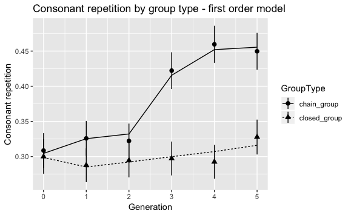

```r
ggplot(df_director, aes(Generation, New_Redup_B, shape=GroupType)) +
  stat_summary(fun.data=mean_se, geom="pointrange") +
  stat_summary(aes(y=fitted(CVC_first_order), linetype=GroupType),
               fun.y=mean, geom="line") +
  ylab("Consonant repetition")+
  ggtitle('Consonant repetition by group type - first order model')
```

```r
dev.print(pdf, 'Consonant repetition by group type - first order model.pdf')
```

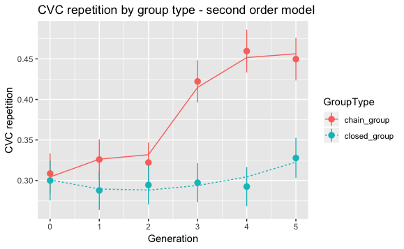

```r
ggplot(df_director, aes(Generation, New_Redup_B, color=GroupType)) +
  stat_summary(fun.data=mean_se, geom="pointrange") +
  stat_summary(aes(y=fitted(CVC_second_order), linetype=GroupType),
               fun.y=mean, geom="line") +
  ylab("CVC repetition")+
  ggtitle('CVC repetition by group type - second order model')
```

```r
dev.print(pdf,'CVC repetition by group type - second order model.pdf')
```

```r
# sjPlot::tab_df(round(coef(summary(CVC_first_order)),3),file='CVC_fixed_effects.doc')
# sjPlot::tab_df(as.numeric(VarCorr(CVC_first_order)),file='CVC_random_effects.doc')
```

## 6.6 CVC: Plots showing model fit of 1st and 2nd order models by lexicon type

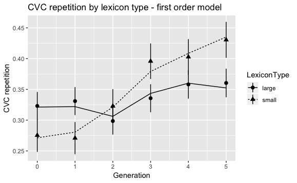

```r
ggplot(df_director, aes(Generation, New_Redup_B, shape=LexiconType)) +
  stat_summary(fun.data=mean_se, geom="pointrange") +
  stat_summary(aes(y=fitted(CVC_first_order), linetype=LexiconType),
               fun.y=mean, geom="line") +
  ylab("CVC repetition") +
  ggtitle('CVC repetition by lexicon type - first order model')
```

```r
dev.print(pdf,'CVC repetition by lexicon type - first order model.pdf')
```

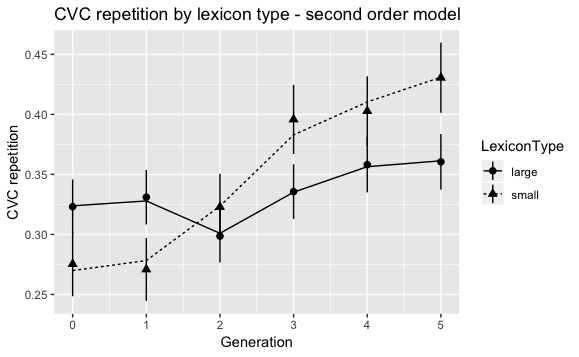

```r
ggplot(df_director, aes(Generation, New_Redup_B, shape=LexiconType)) +
  stat_summary(fun.data=mean_se, geom="pointrange") +
  stat_summary(aes(y=fitted(CVC_second_order), linetype=LexiconType),
               fun.y=mean, geom="line") +
  ylab("CVC repetition") +
  ggtitle('CVC repetition by lexicon type - second order model')
```

```r
dev.print(pdf,'CVC repetition by lexicon type - second order model.pdf')
```

# 7 Analysis of adjacent syllable repetition

## 7.1 Descriptive plot

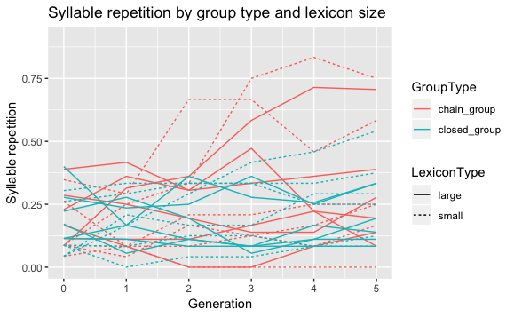

```r
ggplot(df_director_plot, aes(Generation, Adj_B, group = group_id, colour=GroupType, linetype=LexiconType)) +
  stat_summary(fun.data=mean_se, geom="line") +
  ylab("Syllable repetition")+
  ggtitle('Syllable repetition by group type and lexicon size')
```

```r
dev.print(pdf, 'Syllable repetition by group type - dog dinner.pdf')
```

## 7.2 Syllable repetition: Full models

```r
# ADJ_third_order <- glmer(Adj_B ~ #maximal random effect structure, up to cubic term
#                   (ot1+ot2+ot3) * GroupType * LexiconType + (1+ot1+ot2+ot3|Unique_Participant) +
#                   (1+ot1+ot2+ot3 |Meaning) + (1+ot1+ot2+ot3|Pair), data=df_director, family=binomial,
#                   control=glmerControl(optimizer = "bobyqa", optCtrl=list(maxfun=1e5)))
# ADJ_second_order <- glmer(Adj_B ~ #maximal random effect structure, up to quadratic term
#                   (ot1+ot2) * GroupType * LexiconType + (1+ot1+ot2|Unique_Participant) +
#                   (1+ot1+ot2 |Meaning) + (1+ot1+ot2|Pair),
#                   data=df_director, family=binomial,
#                   control=glmerControl(optimizer = "bobyqa", optCtrl=list(maxfun=1e5)))
# ADJ_first_order <- glmer(Adj_B ~ #maximal random effect structure, up to linear term
#                   ot1 * GroupType * LexiconType + (1+ot1|Unique_Participant) +
#                   (1+ot1 |Meaning) + (1+ot1|Pair), data=df_director, family=binomial,
#                   control=glmerControl(optimizer = "bobyqa", optCtrl=list(maxfun=1e5)))
```

## 7.3 Syllable repetition: Reduced models

The full models above also result in singular fit. So they are reduced below.

```r
ADJ_third_order <- glmer(Adj_B ~ #maximal random effect structure, up to cubic term
                         (ot1+ot2+ot3) * GroupType * LexiconType + (1|Unique_Participant) +
                           (1|Meaning), data=df_director, family=binomial,
                         control=glmerControl(optimizer = "bobyqa", optCtrl=list(maxfun=1e5)))
ADJ_second_order <- glmer(Adj_B ~ #maximal random effect structure, up to quadratic term
                      (ot1+ot2) * GroupType * LexiconType + (1|Unique_Participant) +
                        (1|Meaning), data=df_director, family=binomial,
                      control=glmerControl(optimizer = "bobyqa", optCtrl=list(maxfun=1e5)))
ADJ_first_order <- glmer(Adj_B ~ #maximal random effect structure, up to linear term
                        ot1 * GroupType * LexiconType + (1|Unique_Participant) +
                          (1|Meaning), data=df_director, family=binomial,
                        control=glmerControl(optimizer = "bobyqa", optCtrl=list(maxfun=1e5)))
summary(ADJ_third_order)
```

```
Generalized linear mixed model fit by maximum likelihood (Laplace
  Approximation) [glmerMod]
 Family: binomial  ( logit )
Formula:
Adj_B ~ (ot1 + ot2 + ot3) * GroupType * LexiconType + (1 | Unique_Participant) +
    (1 | Meaning)
   Data: df_director
Control: glmerControl(optimizer = "bobyqa", optCtrl = list(maxfun = 1e+05))

     AIC      BIC   logLik deviance df.resid
  4218.0   4332.6  -2091.0   4182.0     4275

Scaled residuals:
    Min      1Q  Median      3Q     Max
-1.5872 -0.5279 -0.3722 -0.2213  5.3613

Random effects:
 Groups             Name        Variance Std.Dev.
 Unique_Participant (Intercept) 0.9826   0.9913
 Meaning            (Intercept) 0.2226   0.4718
Number of obs: 4293, groups:  Unique_Participant, 156; Meaning, 18

Fixed effects:
                            Estimate Std. Error z value Pr(>|z|)
(Intercept)                 -1.53427    0.15990  -9.595  < 2e-16 ***
ot1                          0.58571    0.20926   2.799  0.00513 **
ot2                         -0.04126    0.19946  -0.207  0.83614
ot3                          0.00851    0.17095   0.050  0.96030
GroupType1                   0.11537    0.09952   1.159  0.24635
LexiconType1                 0.05799    0.11335   0.512  0.60896
ot1:GroupType1               0.18242    0.14233   1.282  0.19995
ot2:GroupType1              -0.03445    0.14245  -0.242  0.80890
ot3:GroupType1              -0.10020    0.14278  -0.702  0.48279
ot1:LexiconType1            -0.39684    0.20914  -1.897  0.05777 .
ot2:LexiconType1             0.16562    0.19950   0.830  0.40643
ot3:LexiconType1             0.05031    0.17101   0.294  0.76860
GroupType1:LexiconType1      0.06120    0.09923   0.617  0.53743
ot1:GroupType1:LexiconType1  0.03357    0.14228   0.236  0.81347
ot2:GroupType1:LexiconType1 -0.06016    0.14222  -0.423  0.67230
ot3:GroupType1:LexiconType1  0.06582    0.14275   0.461  0.64475
---
Signif. codes:  0 ‘***’ 0.001 ‘**’ 0.01 ‘*’ 0.05 ‘.’ 0.1 ‘ ’ 1
```

```
Correlation matrix not shown by default, as p = 16 > 12.
Use print(x, correlation=TRUE)  or
    vcov(x)        if you need it
```

```r
summary(ADJ_second_order)
```

```
Generalized linear mixed model fit by maximum likelihood (Laplace
  Approximation) [glmerMod]
 Family: binomial  ( logit )
Formula:
Adj_B ~ (ot1 + ot2) * GroupType * LexiconType + (1 | Unique_Participant) +
    (1 | Meaning)
   Data: df_director
Control: glmerControl(optimizer = "bobyqa", optCtrl = list(maxfun = 1e+05))

     AIC      BIC   logLik deviance df.resid
  4210.8   4299.9  -2091.4   4182.8     4279

Scaled residuals:
    Min      1Q  Median      3Q     Max
-1.5876 -0.5289 -0.3728 -0.2181  5.3221

Random effects:
 Groups             Name        Variance Std.Dev.
 Unique_Participant (Intercept) 0.9814   0.9907
 Meaning            (Intercept) 0.2225   0.4717
Number of obs: 4293, groups:  Unique_Participant, 156; Meaning, 18

Fixed effects:
                             Estimate Std. Error z value Pr(>|z|)
(Intercept)                 -1.544456   0.158929  -9.718   <2e-16 ***
ot1                          0.538404   0.183244   2.938   0.0033 **
ot2                          0.001363   0.175009   0.008   0.9938
GroupType1                   0.137403   0.094201   1.459   0.1447
LexiconType1                 0.064454   0.111876   0.576   0.5645
ot1:GroupType1               0.188905   0.140467   1.345   0.1787
ot2:GroupType1              -0.045908   0.140628  -0.326   0.7441
ot1:LexiconType1            -0.401966   0.183227  -2.194   0.0282 *
ot2:LexiconType1             0.172121   0.174883   0.984   0.3250
GroupType1:LexiconType1      0.055042   0.094117   0.585   0.5587
ot1:GroupType1:LexiconType1  0.036263   0.140436   0.258   0.7962
ot2:GroupType1:LexiconType1 -0.058186   0.140438  -0.414   0.6786
---
Signif. codes:  0 ‘***’ 0.001 ‘**’ 0.01 ‘*’ 0.05 ‘.’ 0.1 ‘ ’ 1

Correlation of Fixed Effects:
```

[output cut: 9 more lines]

```
GrpTyp1:LT1  0.004  0.019 -0.014 -0.063 -0.498  0.032  -0.024  -0.007  0.001
ot1:GT1:LT1 -0.001 -0.015  0.001  0.031 -0.271 -0.129   0.041   0.254  0.134
ot2:GT1:LT1  0.007  0.004 -0.023 -0.022  0.239  0.041  -0.112   0.124  0.301
            GT1:LT o1:GT1:
ot1
ot2
GroupType1
LexiconTyp1
ot1:GrpTyp1
ot2:GrpTyp1
ot1:LxcnTy1
ot2:LxcnTy1
GrpTyp1:LT1
ot1:GT1:LT1  0.385
ot2:GT1:LT1 -0.367 -0.006
```

```r
summary(ADJ_first_order)
```

```
Generalized linear mixed model fit by maximum likelihood (Laplace
  Approximation) [glmerMod]
 Family: binomial  ( logit )
Formula: Adj_B ~ ot1 * GroupType * LexiconType + (1 | Unique_Participant) +
    (1 | Meaning)
   Data: df_director
Control: glmerControl(optimizer = "bobyqa", optCtrl = list(maxfun = 1e+05))

     AIC      BIC   logLik deviance df.resid
  4204.5   4268.1  -2092.2   4184.5     4283

Scaled residuals:
    Min      1Q  Median      3Q     Max
-1.5938 -0.5306 -0.3726 -0.2207  5.5188

Random effects:
 Groups             Name        Variance Std.Dev.
 Unique_Participant (Intercept) 0.9936   0.9968
 Meaning            (Intercept) 0.2226   0.4718
Number of obs: 4293, groups:  Unique_Participant, 156; Meaning, 18

Fixed effects:
                            Estimate Std. Error z value Pr(>|z|)
(Intercept)                 -1.53490    0.15697  -9.778  < 2e-16 ***
ot1                          0.55442    0.16306   3.400 0.000674 ***
GroupType1                   0.12145    0.08699   1.396 0.162683
LexiconType1                 0.07129    0.10900   0.654 0.513052
ot1:GroupType1               0.18883    0.13927   1.356 0.175154
ot1:LexiconType1            -0.29691    0.16308  -1.821 0.068658 .
GroupType1:LexiconType1      0.02557    0.08697   0.294 0.768723
ot1:GroupType1:LexiconType1  0.01512    0.13924   0.109 0.913533
---
Signif. codes:  0 ‘***’ 0.001 ‘**’ 0.01 ‘*’ 0.05 ‘.’ 0.1 ‘ ’ 1

Correlation of Fixed Effects:
            (Intr) ot1    GrpTy1 LxcnT1 ot1:GT1 o1:LT1 GT1:LT
ot1         -0.125
GroupType1  -0.318  0.114
LexiconTyp1 -0.058  0.012  0.023
ot1:GrpTyp1 -0.201  0.363  0.410 -0.011
ot1:LxcnTy1  0.006 -0.104  0.027 -0.177 -0.035
GrpTyp1:LT1  0.020  0.028 -0.108 -0.464  0.052   0.113
ot1:GT1:LT1 -0.006 -0.035  0.051 -0.292 -0.122   0.363  0.410
```

## 7.4 Syllable repetition: Model comparison

```r
ADJ_model.names <- c("ADJ first order","ADJ second order","ADJ third order")
ADJ_summ.table <- do.call(rbind, lapply(list(ADJ_first_order,ADJ_second_order,ADJ_third_order), broom::glance))
ADJ_table.cols <- c("df.residual", "deviance", "AIC")
ADJ_reported.table <- ADJ_summ.table[ADJ_table.cols]
names(ADJ_reported.table) <- c("Resid.Df", "Resid.Dev", "AIC")
ADJ_reported.table[['dAIC']] <-  with(ADJ_reported.table, AIC - min(AIC))
ADJ_reported.table[['AIC_weight']] <- with(ADJ_reported.table, exp(- 0.5 * dAIC) / sum(exp(- 0.5 * dAIC)))
ADJ_reported.table$AIC <- NULL
ADJ_reported.table$AIC_weight <- round(ADJ_reported.table$AIC_weight, 2)
ADJ_reported.table$dAIC <- round(ADJ_reported.table$dAIC, 1)
ADJ_reported.table$Resid.Dev <- round(ADJ_reported.table$Resid.Dev, 2)
row.names(ADJ_reported.table) <- ADJ_model.names
```

```
Setting row names on a tibble is deprecated.
```

```r
View(ADJ_reported.table)
sjPlot::tab_df(ADJ_reported.table,
               file="model comparison _ADJ.doc")
sjPlot::tab_df(round(coef(summary(ADJ_first_order)),3),file='ADJ_fixed_effects.doc')
```

## 7.5 Syllable repetition: Plots showing model fit of 1st and 2nd order models by group type

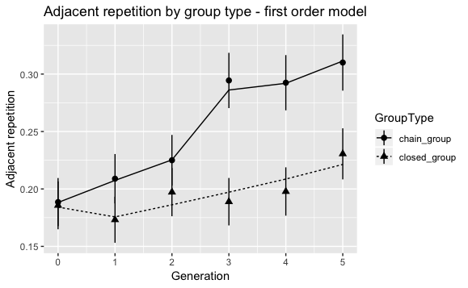

```r
df_director_adj_plots <- subset(df_director, !(is.na(df_director$Adj_B)))

ggplot(df_director_adj_plots, aes(Generation, Adj_B, shape=GroupType)) +
  stat_summary(fun.data=mean_se, geom="pointrange") +
  stat_summary(aes(y=fitted(ADJ_first_order), linetype=GroupType),
               fun.y=mean, geom="line") +
  ylab("Adjacent repetition")+
  ggtitle('Adjacent repetition by group type - first order model')
```

```r
dev.print(pdf,'Adjacent repetition by group type - first order model.pdf')
```

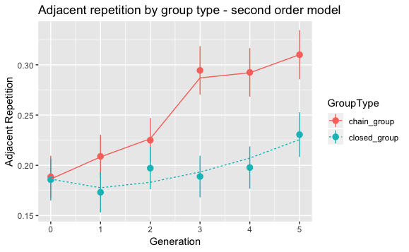

```r
ggplot(df_director_adj_plots, aes(Generation, Adj_B, color=GroupType)) +
  stat_summary(fun.data=mean_se, geom="pointrange") +
  stat_summary(aes(y=fitted(ADJ_second_order), linetype=GroupType),
               fun.y=mean, geom="line") +
  ylab("Adjacent Repetition") +
  ggtitle('Adjacent repetition by group type - second order model')
```

```r
dev.print(pdf,'Adjacent repetition by group type - second order model.pdf')
```

## 7.6 Syllable repetition: Plots showing model fit of 1st and 2nd order models by lexicon type

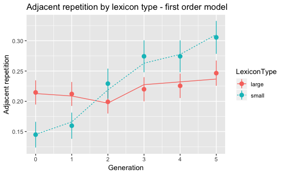

```r
ggplot(df_director_adj_plots, aes(Generation, Adj_B, color=LexiconType)) +
  stat_summary(fun.data=mean_se, geom="pointrange") +
  stat_summary(aes(y=fitted(ADJ_first_order), linetype=LexiconType),
               fun.y=mean, geom="line") +
  ylab("Adjacent repetition")+
  ggtitle('Adjacent repetition by lexicon type - first order model')
```

```r
dev.print(pdf,'Adjacent repetition by lexicon type - first order model.pdf')
```

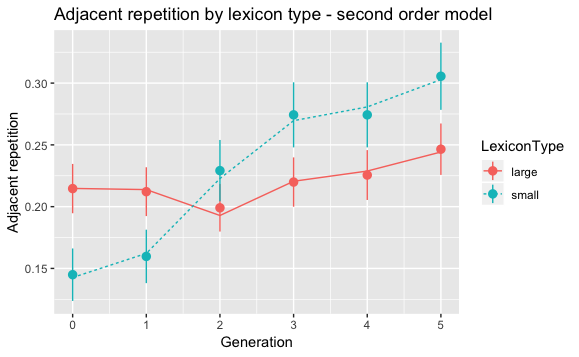

```r
ggplot(df_director_adj_plots, aes(Generation, Adj_B, color=LexiconType)) +
  stat_summary(fun.data=mean_se, geom="pointrange") +
  stat_summary(aes(y=fitted(ADJ_second_order), linetype=LexiconType),
               fun.y=mean, geom="line") +
  ylab("Adjacent repetition")+
  ggtitle('Adjacent repetition by lexicon type - second order model')
```

```r
dev.print(pdf,'Adjacent repetition by lexicon type - second order model.pdf')
```

# 8 Accuracy

## 8.1 Descriptive plot

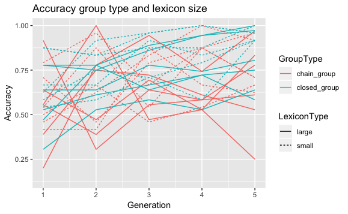

```r
groups2 = ddply(df_matcher, c("GroupType", "LexiconType", "GroupNumber"), summarise, n=length(Block))
groups2$group_id = factor(LETTERS[1:24])
df_matcher_plot = merge(df_matcher, groups, all.x = TRUE)
ggplot(df_matcher_plot, aes(Generation, Score, group = group_id, colour=GroupType, linetype=LexiconType)) +
  stat_summary(fun.data=mean_se, geom="line") +
  ylab("Accuracy")+
  ggtitle('Accuracy group type and lexicon size')
```

```r
dev.print(pdf, 'Accuracy by group type - dog dinner.pdf')
```

## 8.2 Accuracy: Full models

```r
#ACC_first_order <- glmer(Score ~ #maximal random effect structure, up to linear term
#                        ot1 * GroupType * LexiconType  + (1+ot1|Unique_Participant) +
#                       (1+ot1 |Meaning) + (1+ot1|Pair), data=df_matcher, family=binomial,
#                       control=glmerControl(optimizer = "bobyqa", optCtrl=list(maxfun=1e5)))
#ACC_second_order <- glmer(Score ~ #maximal random effect structure, up to quadratic term
#                     (ot1+ot2) * GroupType * LexiconType + (1+ot1+ot2|Unique_Participant) +
#                     (1+ot1+ot2 |Meaning) + (1+ot1+ot2|Pair), data=df_matcher, family=binomial,
#                     control=glmerControl(optimizer = "bobyqa", optCtrl=list(maxfun=1e5)))
#ACC_third_order <- glmer(Score ~ #maximal random effect structure, up to cubic term
#                     (ot1+ot2+ot3) * GroupType * LexiconType + (1+ot1+ot2+ot3|Unique_Participant) +
#                   (1+ot1+ot2+ot3 |Meaning) + (1+ot1+ot2+ot3|Pair), data=df_matcher, family=binomial,
#                   control=glmerControl(optimizer = "bobyqa", optCtrl=list(maxfun=1e5)))
```

## 8.3 Accuracy: Reduced models

The full models above also result in singular fit. So they are reduced below.

```r
ACC_first_order <- glmer(Score ~ #maximal random effect structure, up to linear term
                         ot1 * GroupType * LexiconType + (1|Unique_Participant) + (1|Meaning),
                       data=df_matcher, family=binomial,
                       control=glmerControl(optimizer = "bobyqa", optCtrl=list(maxfun=1e5)))
ACC_second_order <- glmer(Score ~ #maximal random effect structure, up to quadratic term
                      (ot1+ot2) * GroupType * LexiconType + (1|Unique_Participant) + (1|Meaning),
                    data=df_matcher, family=binomial,
                    control=glmerControl(optimizer = "bobyqa", optCtrl=list(maxfun=1e5)))
ACC_third_order <- glmer(Score ~ #maximal random effect structure, up to cubic term
                      (ot1+ot2+ot3) * GroupType * LexiconType + (1|Unique_Participant) + (1|Meaning),
                    data=df_matcher, family=binomial,
                    control=glmerControl(optimizer = "bobyqa", optCtrl=list(maxfun=1e5)))
summary(ACC_third_order)
```

```
Generalized linear mixed model fit by maximum likelihood (Laplace
  Approximation) [glmerMod]
 Family: binomial  ( logit )
Formula:
Score ~ (ot1 + ot2 + ot3) * GroupType * LexiconType + (1 | Unique_Participant) +
    (1 | Meaning)
   Data: df_matcher
Control: glmerControl(optimizer = "bobyqa", optCtrl = list(maxfun = 1e+05))

     AIC      BIC   logLik deviance df.resid
  4070.5   4181.9  -2017.3   4034.5     3575

Scaled residuals:
    Min      1Q  Median      3Q     Max
-6.1190 -0.9143  0.4321  0.6505  1.5580

Random effects:
 Groups             Name        Variance Std.Dev.
 Unique_Participant (Intercept) 0.55055  0.7420
 Meaning            (Intercept) 0.03745  0.1935
Number of obs: 3593, groups:  Unique_Participant, 144; Meaning, 18

Fixed effects:
                            Estimate Std. Error z value Pr(>|z|)
(Intercept)                  1.10906    0.10614  10.449  < 2e-16 ***
ot1                          0.88270    0.12588   7.012 2.35e-12 ***
ot2                         -0.09864    0.12379  -0.797 0.425558
ot3                          0.10352    0.12181   0.850 0.395405
GroupType1                  -0.31792    0.09418  -3.376 0.000736 ***
LexiconType1                -0.32208    0.09513  -3.386 0.000710 ***
ot1:GroupType1              -0.28119    0.12573  -2.236 0.025322 *
ot2:GroupType1              -0.11101    0.12379  -0.897 0.369854
ot3:GroupType1              -0.04318    0.12180  -0.355 0.722946
ot1:LexiconType1            -0.31164    0.12576  -2.478 0.013209 *
ot2:LexiconType1            -0.07789    0.12379  -0.629 0.529213
ot3:LexiconType1             0.06388    0.12182   0.524 0.600049
GroupType1:LexiconType1      0.08920    0.09413   0.948 0.343319
ot1:GroupType1:LexiconType1  0.02448    0.12572   0.195 0.845639
ot2:GroupType1:LexiconType1  0.12381    0.12379   1.000 0.317238
ot3:GroupType1:LexiconType1  0.16946    0.12183   1.391 0.164259
---
Signif. codes:  0 ‘***’ 0.001 ‘**’ 0.01 ‘*’ 0.05 ‘.’ 0.1 ‘ ’ 1
```

```
Correlation matrix not shown by default, as p = 16 > 12.
Use print(x, correlation=TRUE)  or
    vcov(x)        if you need it
```

```r
summary(ACC_second_order)
```

```
Generalized linear mixed model fit by maximum likelihood (Laplace
  Approximation) [glmerMod]
 Family: binomial  ( logit )
Formula:
Score ~ (ot1 + ot2) * GroupType * LexiconType + (1 | Unique_Participant) +
    (1 | Meaning)
   Data: df_matcher
Control: glmerControl(optimizer = "bobyqa", optCtrl = list(maxfun = 1e+05))

     AIC      BIC   logLik deviance df.resid
  4065.3   4151.9  -2018.7   4037.3     3579

Scaled residuals:
    Min      1Q  Median      3Q     Max
-5.6764 -0.9113  0.4319  0.6498  1.6065

Random effects:
 Groups             Name        Variance Std.Dev.
 Unique_Participant (Intercept) 0.55588  0.7456
 Meaning            (Intercept) 0.03741  0.1934
Number of obs: 3593, groups:  Unique_Participant, 144; Meaning, 18

Fixed effects:
                            Estimate Std. Error z value Pr(>|z|)
(Intercept)                  1.10628    0.10634  10.403  < 2e-16 ***
ot1                          0.87276    0.12473   6.997 2.61e-12 ***
ot2                         -0.11617    0.12191  -0.953 0.340617
GroupType1                  -0.31668    0.09441  -3.354 0.000796 ***
LexiconType1                -0.32036    0.09537  -3.359 0.000781 ***
ot1:GroupType1              -0.27350    0.12458  -2.195 0.028134 *
ot2:GroupType1              -0.08912    0.12190  -0.731 0.464743
ot1:LexiconType1            -0.30254    0.12461  -2.428 0.015183 *
ot2:LexiconType1            -0.06219    0.12190  -0.510 0.609955
GroupType1:LexiconType1      0.08662    0.09437   0.918 0.358681
ot1:GroupType1:LexiconType1  0.01577    0.12457   0.127 0.899269
ot2:GroupType1:LexiconType1  0.10388    0.12190   0.852 0.394120
---
Signif. codes:  0 ‘***’ 0.001 ‘**’ 0.01 ‘*’ 0.05 ‘.’ 0.1 ‘ ’ 1

Correlation of Fixed Effects:
```

[output cut: 9 more lines]

```
GrpTyp1:LT1  0.031  0.042  0.023 -0.079 -0.559 -0.065  -0.018  -0.056 -0.021
ot1:GT1:LT1  0.035  0.111  0.063 -0.065 -0.055 -0.234  -0.082   0.245 -0.072
ot2:GT1:LT1  0.022  0.063  0.079 -0.018 -0.021 -0.082  -0.202  -0.072  0.296
            GT1:LT o1:GT1:
ot1
ot2
GroupType1
LexiconTyp1
ot1:GrpTyp1
ot2:GrpTyp1
ot1:LxcnTy1
ot2:LxcnTy1
GrpTyp1:LT1
ot1:GT1:LT1  0.083
ot2:GT1:LT1  0.019  0.112
```

```r
summary(ACC_first_order)
```

```
Generalized linear mixed model fit by maximum likelihood (Laplace
  Approximation) [glmerMod]
 Family: binomial  ( logit )
Formula: Score ~ ot1 * GroupType * LexiconType + (1 | Unique_Participant) +
    (1 | Meaning)
   Data: df_matcher
Control: glmerControl(optimizer = "bobyqa", optCtrl = list(maxfun = 1e+05))

     AIC      BIC   logLik deviance df.resid
  4060.2   4122.1  -2020.1   4040.2     3583

Scaled residuals:
    Min      1Q  Median      3Q     Max
-5.3773 -0.9108  0.4328  0.6502  1.6203

Random effects:
 Groups             Name        Variance Std.Dev.
 Unique_Participant (Intercept) 0.56201  0.7497
 Meaning            (Intercept) 0.03734  0.1932
Number of obs: 3593, groups:  Unique_Participant, 144; Meaning, 18

Fixed effects:
                             Estimate Std. Error z value Pr(>|z|)
(Intercept)                  1.105108   0.106587  10.368  < 2e-16 ***
ot1                          0.870556   0.123001   7.078 1.47e-12 ***
GroupType1                  -0.314923   0.094714  -3.325 0.000884 ***
LexiconType1                -0.318162   0.095662  -3.326 0.000881 ***
ot1:GroupType1              -0.263141   0.122847  -2.142 0.032192 *
ot1:LexiconType1            -0.288397   0.122878  -2.347 0.018924 *
GroupType1:LexiconType1      0.084818   0.094668   0.896 0.370279
ot1:GroupType1:LexiconType1 -0.003059   0.122841  -0.025 0.980136
---
Signif. codes:  0 ‘***’ 0.001 ‘**’ 0.01 ‘*’ 0.05 ‘.’ 0.1 ‘ ’ 1

Correlation of Fixed Effects:
            (Intr) ot1    GrpTy1 LxcnT1 ot1:GT1 o1:LT1 GT1:LT
ot1          0.074
GroupType1  -0.500 -0.046
LexiconTyp1 -0.090 -0.058  0.031
ot1:GrpTyp1 -0.041  0.293  0.077  0.030
ot1:LxcnTy1 -0.052 -0.204  0.030  0.077  0.075
GrpTyp1:LT1  0.029  0.031 -0.077 -0.559 -0.056  -0.047
ot1:GT1:LT1  0.026  0.074 -0.056 -0.046 -0.203   0.293  0.076
```

## 8.4 Accuracy: Model comparison

```r
ACC_model.names <- c("ACC first order","ACC second order","ACC third order")
ACC_summ.table <- do.call(rbind, lapply(list(ACC_first_order,ACC_second_order,ACC_third_order), broom::glance))
ACC_table.cols <- c("df.residual", "deviance", "AIC")
ACC_reported.table <- ACC_summ.table[ACC_table.cols]
names(ACC_reported.table) <- c("Resid.Df", "Resid.Dev", "AIC")
ACC_reported.table[['dAIC']] <-  with(ACC_reported.table, AIC - min(AIC))
ACC_reported.table[['AIC_weight']] <- with(ACC_reported.table, exp(- 0.5 * dAIC) / sum(exp(- 0.5 * dAIC)))
ACC_reported.table$AIC <- NULL
ACC_reported.table$dAIC <- round(ACC_reported.table$dAIC, 1)
ACC_reported.table$AIC_weight <- round(ACC_reported.table$AIC_weight, 2)
ACC_reported.table$Resid.Dev <- round(ACC_reported.table$Resid.Dev, 2)
row.names(ACC_reported.table) <- ACC_model.names
```

```
Setting row names on a tibble is deprecated.
```

```r
View(ACC_reported.table)
sjPlot::tab_df(ACC_reported.table,
               file="model comparison _ACC.doc")
```

## 8.5 Accuracy: Plots showing model fit of 1st and 2nd order models by group type

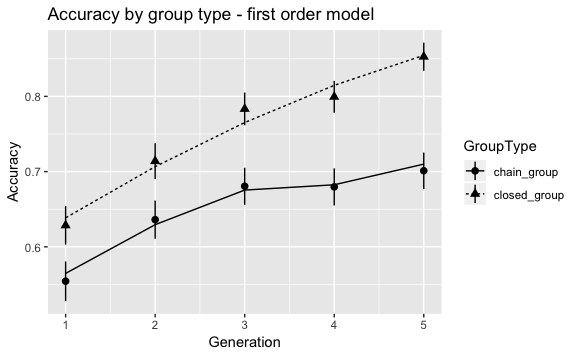

```r
ggplot(df_matcher, aes(Generation, Score, shape=GroupType)) +
  stat_summary(fun.data=mean_se, geom="pointrange") +
  stat_summary(aes(y=fitted(ACC_first_order), linetype=GroupType),
               fun.y=mean, geom="line") +
  ylab("Accuracy")+
  ggtitle('Accuracy by group type - first order model')
```

```r
dev.print(pdf,'Accuracy by group type - first order model.pdf')
```

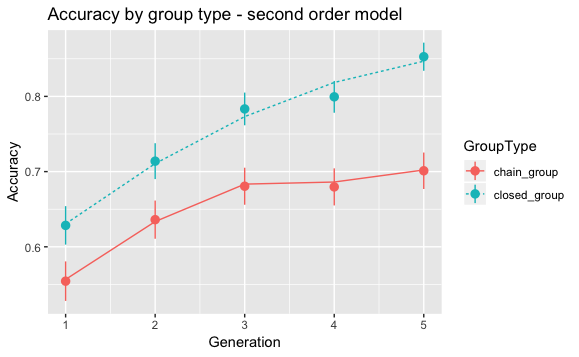

```r
ggplot(df_matcher, aes(Generation, Score, color=GroupType)) +
  stat_summary(fun.data=mean_se, geom="pointrange") +
  stat_summary(aes(y=fitted(ACC_second_order), linetype=GroupType),
               fun.y=mean, geom="line") +
  ylab("Accuracy")+
  ggtitle('Accuracy by group type - second order model')
```

```r
dev.print(pdf,'Accuracy by group type - second order model.pdf')
```

## 8.6 Accuracy: Plots showing model fit of 1st and 2nd order models by lexicon type

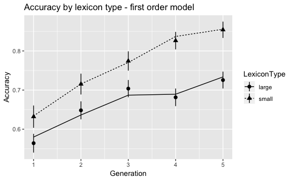

```r
ggplot(df_matcher, aes(Generation, Score, shape=LexiconType)) +
  stat_summary(fun.data=mean_se, geom="pointrange") +
  stat_summary(aes(y=fitted(ACC_first_order), linetype=LexiconType),
               fun.y=mean, geom="line") +
  ylab("Accuracy")+
  ggtitle('Accuracy by lexicon type - first order model')
```

```r
dev.print(pdf,'Accuracy by lexicon type - first order model.pdf')
```

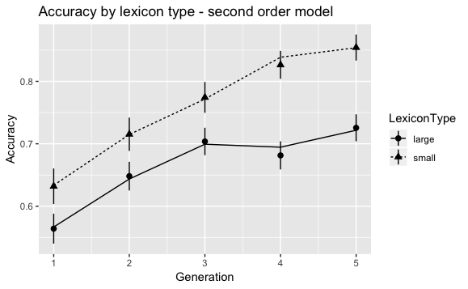

```r
ggplot(df_matcher, aes(Generation, Score, shape=LexiconType)) +
  stat_summary(fun.data=mean_se, geom="pointrange") +
  stat_summary(aes(y=fitted(ACC_second_order), linetype=LexiconType),
               fun.y=mean, geom="line") +
  ylab("Accuracy")+
  ggtitle('Accuracy by lexicon type - second order model')
```

```r
dev.print(pdf,'Accuracy by lexicon type - second order model.pdf')
```

```r
sjPlot::tab_df(round(coef(summary(ACC_first_order)),3),file='ACC_fixed_effects.doc')
```

# 9 Homonymy

## 9.1 Coding homonymy

These are based on iteration 2 only. Homonymy is calculated as proportions.

```r
df_homonymy<-setNames(aggregate(df_director_generations_1_to_5$New_Redup_B, by=list(df_director_generations_1_to_5$GroupType,df_director_generations_1_to_5$LexiconType,df_director_generations_1_to_5$GroupNumber,df_director_generations_1_to_5$Generation,df_director_generations_1_to_5$Unique_language,df_director_generations_1_to_5$Pair, df_director_generations_1_to_5$Unique_Participant), FUN=mean),c('GroupType','LexiconType','GroupNumber','Generation','Unique_language','Pair', 'Unique_Participant','New_Redup_B_mean'))
df_homonymy$Word_repetition<-NA
for(i in unique(df_homonymy$Unique_language)){
  subs_ <- subset(df_director_generations_1_to_5,Unique_language==i)
  for(j in 1:nrow(df_homonymy)){
    if(toString(df_homonymy[j,]$Unique_language) == i){
      df_homonymy[j,]$Word_repetition <- (length(subs_$TypedLabel)-length(unique(subs_$TypedLabel)))/length(subs_$TypedLabel)

    }
  }
}
initial_languages<-subset(df_director,Generation==0)
df_initial_languages <-setNames(aggregate(initial_languages$New_Redup_B, by=list(initial_languages$GroupType,initial_languages$LexiconType,initial_languages$GroupNumber,initial_languages$Generation,initial_languages$Unique_language,initial_languages$Pair, initial_languages$Unique_Participant), FUN=mean),c('GroupType','LexiconType','GroupNumber','Generation','Unique_language','Pair', 'Unique_Participant','New_Redup_B_mean'))
df_initial_languages$Word_repetition <-0
df_homonymy<-rbind(df_initial_languages,df_homonymy)
df_homonymy_1_to_5 <- subset(df_homonymy, Generation>0) #generations 1 to 5
cor(df_homonymy_1_to_5$New_Redup_B_mean,df_homonymy_1_to_5$Word_repetition) #looking at mean CVC redup. When looking at sum CVC redup the correlation was .20...
```

```
[1] 0.176133
```

```r
df_homonymy$timebin = df_homonymy$Generation + 1
t_ = poly(unique(df_homonymy$timebin), 3)
df_homonymy[,paste("ot", 1:3, sep="")] <- t_[df_homonymy$timebin, 1:3]
contrasts(df_homonymy$LexiconType) = contr.sum(2)
contrasts(df_homonymy$GroupType) = contr.sum(2)
```

## 9.2 Homonymy: Models

Can’t fit a 3rd order model because there are fewer observations than random effects

```r
homonymy_first_order <- lmer(Word_repetition ~
                          ot1*GroupType*LexiconType +
                          (1|Unique_Participant),
                        data=df_homonymy, control=lmerControl(optimizer = "bobyqa", optCtrl=list(maxfun=2e5)))
homonymy_second_order <- lmer(Word_repetition ~
                          (ot1+ot2)*GroupType*LexiconType +
                            (1|Unique_Participant),
                        data=df_homonymy, control=lmerControl(optimizer = "bobyqa", optCtrl=list(maxfun=2e5)))
summary(homonymy_first_order)
```

```
Linear mixed model fit by REML. t-tests use Satterthwaite's method [
lmerModLmerTest]
Formula:
Word_repetition ~ ot1 * GroupType * LexiconType + (1 | Unique_Participant)
   Data: df_homonymy
Control: lmerControl(optimizer = "bobyqa", optCtrl = list(maxfun = 2e+05))

REML criterion at convergence: -718.7

Scaled residuals:
     Min       1Q   Median       3Q      Max
-2.66121 -0.35552 -0.06661  0.27156  2.99173

Random effects:
 Groups             Name        Variance Std.Dev.
 Unique_Participant (Intercept) 0.006034 0.07768
 Residual                       0.001311 0.03621
Number of obs: 288, groups:  Unique_Participant, 156

Fixed effects:
                              Estimate Std. Error         df t value
(Intercept)                  6.252e-02  7.815e-03  1.326e+02   8.000
ot1                          3.912e-02  1.036e-02  2.659e+02   3.776
GroupType1                   3.999e-02  5.768e-03  2.219e+02   6.933
LexiconType1                 3.035e-03  7.815e-03  1.326e+02   0.388
ot1:GroupType1               6.701e-02  9.056e-03  2.242e+02   7.400
ot1:LexiconType1             3.169e-02  1.036e-02  2.659e+02   3.059
GroupType1:LexiconType1      3.654e-04  5.768e-03  2.219e+02   0.063
ot1:GroupType1:LexiconType1 -1.794e-03  9.056e-03  2.242e+02  -0.198
                            Pr(>|t|)
(Intercept)                 5.47e-13 ***
ot1                         0.000196 ***
GroupType1                  4.44e-11 ***
LexiconType1                0.698384
ot1:GroupType1              2.72e-12 ***
ot1:LexiconType1            0.002445 **
GroupType1:LexiconType1     0.949542
ot1:GroupType1:LexiconType1 0.843179
---
Signif. codes:  0 ‘***’ 0.001 ‘**’ 0.01 ‘*’ 0.05 ‘.’ 0.1 ‘ ’ 1

Correlation of Fixed Effects:
            (Intr) ot1    GrpTy1 LxcnT1 ot1:GT1 o1:LT1 GT1:LT
ot1         -0.254
GroupType1  -0.494  0.321
LexiconTyp1  0.000  0.000  0.000
ot1:GrpTyp1 -0.384  0.542  0.628  0.000
ot1:LxcnTy1  0.000  0.000  0.000 -0.254  0.000
GrpTyp1:LT1  0.000  0.000  0.000 -0.494  0.000   0.321
ot1:GT1:LT1  0.000  0.000  0.000 -0.384  0.000   0.542  0.628
```

```r
summary(homonymy_second_order)
```

```
Linear mixed model fit by REML. t-tests use Satterthwaite's method [
lmerModLmerTest]
Formula: Word_repetition ~ (ot1 + ot2) * GroupType * LexiconType + (1 |
    Unique_Participant)
   Data: df_homonymy
Control: lmerControl(optimizer = "bobyqa", optCtrl = list(maxfun = 2e+05))

REML criterion at convergence: -689.3

Scaled residuals:
     Min       1Q   Median       3Q      Max
-2.59096 -0.35469 -0.04545  0.26614  2.92943

Random effects:
 Groups             Name        Variance Std.Dev.
 Unique_Participant (Intercept) 0.006162 0.07850
 Residual                       0.001319 0.03632
Number of obs: 288, groups:  Unique_Participant, 156

Fixed effects:
                              Estimate Std. Error         df t value
(Intercept)                  6.186e-02  8.292e-03  1.180e+02   7.459
ot1                          3.810e-02  1.172e-02  2.670e+02   3.252
ot2                         -4.644e-04  1.139e-02  2.617e+02  -0.041
GroupType1                   4.095e-02  6.669e-03  1.641e+02   6.140
LexiconType1                 2.533e-03  8.292e-03  1.180e+02   0.306
ot1:GroupType1               6.697e-02  9.236e-03  2.191e+02   7.252
ot2:GroupType1              -2.572e-03  9.293e-03  2.162e+02  -0.277
ot1:LexiconType1             3.407e-02  1.172e-02  2.670e+02   2.907
ot2:LexiconType1            -5.874e-03  1.139e-02  2.617e+02  -0.516
GroupType1:LexiconType1      4.063e-04  6.669e-03  1.641e+02   0.061
ot1:GroupType1:LexiconType1 -2.523e-03  9.236e-03  2.191e+02  -0.273
ot2:GroupType1:LexiconType1 -1.263e-03  9.293e-03  2.162e+02  -0.136
                            Pr(>|t|)
(Intercept)                 1.61e-11 ***
ot1                          0.00129 **
ot2                          0.96750
GroupType1                  6.00e-09 ***
LexiconType1                 0.76052
ot1:GroupType1              7.00e-12 ***
```

[output cut: 19 more lines]

```
GrpTyp1:LT1  0.000  0.000  0.000  0.000 -0.551  0.000   0.000   0.135 -0.127
ot1:GT1:LT1  0.000  0.000  0.000  0.000 -0.336  0.000   0.000   0.432  0.152
ot2:GT1:LT1  0.000  0.000  0.000  0.000  0.305  0.000   0.000   0.146  0.469
            GT1:LT o1:GT1:
ot1
ot2
GroupType1
LexiconTyp1
ot1:GrpTyp1
ot2:GrpTyp1
ot1:LxcnTy1
ot2:LxcnTy1
GrpTyp1:LT1
ot1:GT1:LT1  0.526
ot2:GT1:LT1 -0.477  0.068
```

## 9.3 Homonymy: Model comparison

```r
homonyms_model.names <- c("Homonymy first order","Homonymy second order")
homonyms_summ.table <- do.call(rbind, lapply(list(homonymy_first_order,homonymy_second_order), broom::glance))
homonyms_table.cols <- c("df.residual", "deviance", "AIC")
homonyms_reported.table <- homonyms_summ.table[homonyms_table.cols]
names(homonyms_reported.table) <- c("Resid. Df", "Resid.Dev", "AIC")
homonyms_reported.table[['dAIC']] <-  with(homonyms_reported.table, AIC - min(AIC))
homonyms_reported.table[['AIC_weight']] <- with(homonyms_reported.table, exp(- 0.5 * dAIC) / sum(exp(- 0.5 * dAIC)))
homonyms_reported.table$AIC <- NULL
homonyms_reported.table$AIC_weight <- round(homonyms_reported.table$AIC_weight, 2)
homonyms_reported.table$dAIC <- round(homonyms_reported.table$dAIC, 1)
homonyms_reported.table$Resid.Dev <- round(homonyms_reported.table$Resid.Dev, 2)
row.names(homonyms_reported.table) <- homonyms_model.names
```

```
Setting row names on a tibble is deprecated.
```

```r
View(homonyms_reported.table)
anova(homonymy_first_order,homonymy_second_order)
```

```
refitting model(s) with ML (instead of REML)
```

```
Data: df_homonymy
Models:
homonymy_first_order: Word_repetition ~ ot1 * GroupType * LexiconType + (1 | Unique_Participant)
homonymy_second_order: Word_repetition ~ (ot1 + ot2) * GroupType * LexiconType + (1 |
homonymy_second_order:     Unique_Participant)
                      Df     AIC     BIC logLik deviance  Chisq Chi Df
homonymy_first_order  10 -763.57 -726.94 391.79  -783.57
homonymy_second_order 14 -755.95 -704.67 391.97  -783.95 0.3756      4
                      Pr(>Chisq)
homonymy_first_order
homonymy_second_order     0.9844
```

```r
sjPlot::tab_df(homonyms_reported.table,
               file="model comparison homonyms_.doc")
sjPlot::tab_df(round(coef(summary(homonymy_first_order)),3),file='homonyms_fixed_effects.doc')
```

## 9.4 Homonymy: Plots showing model fit of 1st and 2nd order models by group type

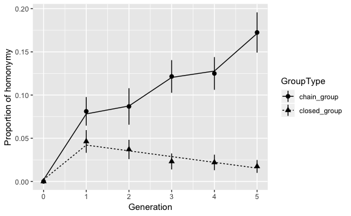

```r
ggplot(df_homonymy, aes(Generation, Word_repetition, shape=GroupType)) +
  stat_summary(fun.data=mean_se, geom="pointrange") +
  stat_summary(aes(y=fitted(homonymy_first_order), linetype=GroupType),
               fun.y=mean, geom="line") +
  ylab("Proportion of homonymy")
```

```r
dev.print(pdf,'Homonymy by group type - first order model.pdf')
```

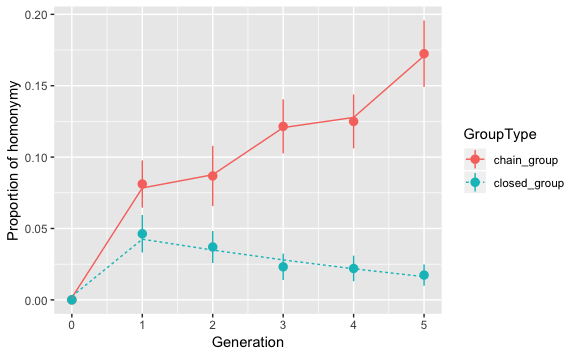

```r
ggplot(df_homonymy, aes(Generation, Word_repetition, color=GroupType)) +
  stat_summary(fun.data=mean_se, geom="pointrange") +
  stat_summary(aes(y=fitted(homonymy_second_order), linetype=GroupType),
               fun.y=mean, geom="line") +
  ylab("Proportion of homonymy")
```

```r
dev.print(pdf,'Homonymy by group type - second order model.pdf')
```

## 9.5 Homonymy: Plots showing model fit of 1st and 2nd order models by lexicon type

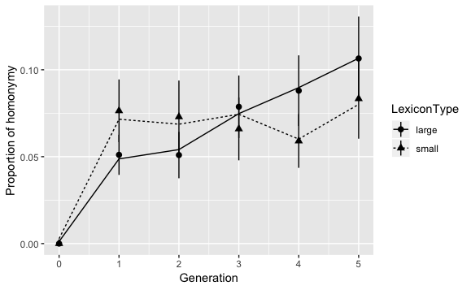

```r
ggplot(df_homonymy, aes(Generation, Word_repetition, shape=LexiconType)) +
  stat_summary(fun.data=mean_se, geom="pointrange") +
  stat_summary(aes(y=fitted(homonymy_first_order), linetype=LexiconType),
               fun.y=mean, geom="line") +
  ylab("Proportion of homonymy")
```

```r
dev.print(pdf,'Homonymy by lexicon type - first order model.pdf')
```

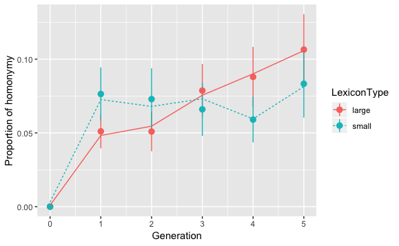

```r
ggplot(df_homonymy, aes(Generation, Word_repetition, color=LexiconType)) +
  stat_summary(fun.data=mean_se, geom="pointrange") +
  stat_summary(aes(y=fitted(homonymy_second_order), linetype=LexiconType),
               fun.y=mean, geom="line") +
  ylab("Proportion of homonymy")
```

```r
dev.print(pdf,'Homonymy by lexicon type - second order model.pdf')
```

# 10 Homonymy: Logistic analysis

Analyze homonymy again, using 0/1 coding for word repetition and binomial stats

## 10.1 Homonymy (log): Models

```r
df_homonymy$Word_repetition_binary = ifelse(df_homonymy$Word_repetition > 0, 1, 0)
homonymy_first_order_log <- glmer(Word_repetition_binary ~
                               ot1*GroupType*LexiconType + (1|Unique_Participant),
                             data=df_homonymy, family=binomial,
                             control=glmerControl(optimizer = "bobyqa", optCtrl=list(maxfun=1e5)))
homonymy_second_order_log <- glmer(Word_repetition_binary ~
                                    (ot1+ot2)*GroupType*LexiconType + (1|Unique_Participant),
                                  data=df_homonymy, family=binomial,
                                  control=glmerControl(optimizer = "bobyqa", optCtrl=list(maxfun=1e5)))
homonymy_third_order_log <- glmer(Word_repetition_binary ~
                                     (ot1+ot2+ot3)*GroupType*LexiconType + (1|Unique_Participant),
                                   data=df_homonymy, family=binomial,
                                  control=glmerControl(optimizer = "bobyqa", optCtrl=list(maxfun=1e5)))
summary(homonymy_first_order_log)
```

```
Generalized linear mixed model fit by maximum likelihood (Laplace
  Approximation) [glmerMod]
 Family: binomial  ( logit )
Formula: Word_repetition_binary ~ ot1 * GroupType * LexiconType + (1 |
    Unique_Participant)
   Data: df_homonymy
Control: glmerControl(optimizer = "bobyqa", optCtrl = list(maxfun = 1e+05))

     AIC      BIC   logLik deviance df.resid
   305.7    338.7   -143.9    287.7      279

Scaled residuals:
    Min      1Q  Median      3Q     Max
-2.3399 -0.4370 -0.1921  0.3336  2.0135

Random effects:
 Groups             Name        Variance Std.Dev.
 Unique_Participant (Intercept) 3.286    1.813
Number of obs: 288, groups:  Unique_Participant, 156

Fixed effects:
                            Estimate Std. Error z value Pr(>|z|)
(Intercept)                 -0.16379    0.26493  -0.618 0.536432
ot1                          1.69728    0.57580   2.948 0.003201 **
GroupType1                   1.58281    0.43196   3.664 0.000248 ***
LexiconType1                 0.23858    0.28474   0.838 0.402103
ot1:GroupType1               2.67830    0.77586   3.452 0.000556 ***
ot1:LexiconType1             0.27372    0.58093   0.471 0.637519
GroupType1:LexiconType1     -0.03297    0.25705  -0.128 0.897942
ot1:GroupType1:LexiconType1 -1.36152    0.59300  -2.296 0.021676 *
---
Signif. codes:  0 ‘***’ 0.001 ‘**’ 0.01 ‘*’ 0.05 ‘.’ 0.1 ‘ ’ 1

Correlation of Fixed Effects:
            (Intr) ot1    GrpTy1 LxcnT1 ot1:GT1 o1:LT1 GT1:LT
ot1          0.048
GroupType1  -0.121  0.081
LexiconTyp1 -0.007 -0.049  0.287
ot1:GrpTyp1  0.008  0.230  0.670  0.307
ot1:LxcnTy1 -0.073 -0.163  0.154  0.096  0.063
GrpTyp1:LT1 -0.029  0.044 -0.157 -0.305 -0.182   0.014
ot1:GT1:LT1  0.033 -0.093 -0.411 -0.195 -0.438   0.164  0.248
```

```r
summary(homonymy_second_order_log)
```

```
Generalized linear mixed model fit by maximum likelihood (Laplace
  Approximation) [glmerMod]
 Family: binomial  ( logit )
Formula: Word_repetition_binary ~ (ot1 + ot2) * GroupType * LexiconType +
    (1 | Unique_Participant)
   Data: df_homonymy
Control: glmerControl(optimizer = "bobyqa", optCtrl = list(maxfun = 1e+05))

     AIC      BIC   logLik deviance df.resid
   298.8    346.5   -136.4    272.8      275

Scaled residuals:
    Min      1Q  Median      3Q     Max
-2.4415 -0.4328 -0.1880  0.3536  3.5588

Random effects:
 Groups             Name        Variance Std.Dev.
 Unique_Participant (Intercept) 1.361    1.167
Number of obs: 288, groups:  Unique_Participant, 156

Fixed effects:
                            Estimate Std. Error z value Pr(>|z|)
(Intercept)                 -0.31709    0.22011  -1.441 0.149696
ot1                          1.83969    0.53858   3.416 0.000636 ***
ot2                         -1.84158    0.52716  -3.493 0.000477 ***
GroupType1                   1.26953    0.28193   4.503  6.7e-06 ***
LexiconType1                 0.20317    0.22319   0.910 0.362680
ot1:GroupType1               2.18125    0.60706   3.593 0.000327 ***
ot2:GroupType1              -0.14429    0.49813  -0.290 0.772074
ot1:LexiconType1             0.35009    0.52733   0.664 0.506759
ot2:LexiconType1             0.09551    0.51961   0.184 0.854155
GroupType1:LexiconType1      0.01316    0.21285   0.062 0.950700
ot1:GroupType1:LexiconType1 -1.30560    0.52323  -2.495 0.012585 *
ot2:GroupType1:LexiconType1 -0.68910    0.49401  -1.395 0.163042
---
Signif. codes:  0 ‘***’ 0.001 ‘**’ 0.01 ‘*’ 0.05 ‘.’ 0.1 ‘ ’ 1

Correlation of Fixed Effects:
            (Intr) ot1    ot2    GrpTy1 LxcnT1 ot1:GT1 ot2:GT1 o1:LT1 o2:LT1
ot1          0.010
ot2          0.265 -0.162
GroupType1  -0.183  0.098 -0.139
LexiconTyp1 -0.112 -0.098 -0.184  0.132
ot1:GrpTyp1 -0.108  0.132 -0.173  0.437  0.215
ot2:GrpTyp1 -0.007 -0.125  0.083  0.023 -0.048 -0.130
ot1:LxcnTy1 -0.146 -0.151 -0.149  0.136  0.038  0.031   0.135
ot2:LxcnTy1 -0.157 -0.139 -0.180 -0.016  0.251  0.131   0.036  -0.131
GrpTyp1:LT1  0.018  0.122 -0.014 -0.094 -0.177 -0.142  -0.154  -0.057 -0.038
ot1:GT1:LT1  0.154 -0.059  0.198 -0.291 -0.124 -0.320  -0.094   0.001 -0.092
ot2:GT1:LT1 -0.005  0.117  0.057 -0.204 -0.044 -0.195  -0.162  -0.097  0.054
            GT1:LT o1:GT1:
ot1
ot2
GroupType1
LexiconTyp1
ot1:GrpTyp1
ot2:GrpTyp1
ot1:LxcnTy1
ot2:LxcnTy1
GrpTyp1:LT1
ot1:GT1:LT1  0.114
ot2:GT1:LT1  0.191  0.000
```

```r
summary(homonymy_third_order_log)
```

```
Generalized linear mixed model fit by maximum likelihood (Laplace
  Approximation) [glmerMod]
 Family: binomial  ( logit )
Formula:
Word_repetition_binary ~ (ot1 + ot2 + ot3) * GroupType * LexiconType +
    (1 | Unique_Participant)
   Data: df_homonymy
Control: glmerControl(optimizer = "bobyqa", optCtrl = list(maxfun = 1e+05))

     AIC      BIC   logLik deviance df.resid
   293.0    355.3   -129.5    259.0      271

Scaled residuals:
    Min      1Q  Median      3Q     Max
-2.7747 -0.4301 -0.1310  0.3791  2.0874

Random effects:
 Groups             Name        Variance Std.Dev.
 Unique_Participant (Intercept) 1.301    1.141
Number of obs: 288, groups:  Unique_Participant, 156

Fixed effects:
                             Estimate Std. Error z value Pr(>|z|)
(Intercept)                 -0.440247   0.238064  -1.849 0.064417 .
ot1                          2.573285   0.662650   3.883 0.000103 ***
ot2                         -2.181392   0.622676  -3.503 0.000460 ***
ot3                          1.592944   0.526002   3.028 0.002459 **
GroupType1                   1.232435   0.284710   4.329  1.5e-05 ***
LexiconType1                 0.169306   0.239656   0.706 0.479905
ot1:GroupType1               1.920450   0.677763   2.834 0.004604 **
ot2:GroupType1              -0.116931   0.570672  -0.205 0.837649
ot3:GroupType1              -0.227157   0.499726  -0.455 0.649423
ot1:LexiconType1             0.183170   0.631328   0.290 0.771714
ot2:LexiconType1            -0.041502   0.589329  -0.070 0.943857
ot3:LexiconType1            -0.059721   0.513425  -0.116 0.907400
GroupType1:LexiconType1     -0.005999   0.231297  -0.026 0.979308
ot1:GroupType1:LexiconType1 -1.041604   0.619715  -1.681 0.092806 .
ot2:GroupType1:LexiconType1 -0.657437   0.570436  -1.153 0.249109
ot3:GroupType1:LexiconType1  0.787134   0.512633   1.535 0.124667
---
Signif. codes:  0 ‘***’ 0.001 ‘**’ 0.01 ‘*’ 0.05 ‘.’ 0.1 ‘ ’ 1
```

```
Correlation matrix not shown by default, as p = 16 > 12.
Use print(x, correlation=TRUE)  or
    vcov(x)        if you need it
```

```r
numcols <- grep("^c\\.",names(df_homonymy))
dfs_homonymy <- df_homonymy
dfs_homonymy[,numcols] <- scale(dfs_homonymy[,numcols])
homonymy_first_order_log_sc <- update(homonymy_first_order_log, data=dfs_homonymy)
homonymy_second_order_log_sc <- update(homonymy_second_order_log, data=dfs_homonymy)
```

## 10.2 Homonymy (log): Model comparison

```r
homonyms_log_model.names <- c("Homonymy first order log","Homonymy second order log", "Homonymy third order log")
homonyms_log_summ.table <- do.call(rbind, lapply(list(homonymy_first_order_log,homonymy_second_order, homonymy_third_order_log), broom::glance))
homonyms_log_table.cols <- c("df.residual", "deviance", "AIC")
homonyms_log_reported.table <- homonyms_log_summ.table[homonyms_log_table.cols]
names(homonyms_log_reported.table) <- c("Resid. Df", "Resid.Dev", "AIC")
homonyms_log_reported.table[['dAIC']] <-  with(homonyms_log_reported.table, AIC - min(AIC))
homonyms_log_reported.table[['AIC_weight']] <- with(homonyms_log_reported.table, exp(- 0.5 * dAIC) / sum(exp(- 0.5 * dAIC)))
homonyms_log_reported.table$AIC <- NULL
homonyms_log_reported.table$AIC_weight <- round(homonyms_log_reported.table$AIC_weight, 2)
homonyms_log_reported.table$dAIC <- round(homonyms_log_reported.table$dAIC, 1)
homonyms_log_reported.table$Resid.Dev <- round(homonyms_log_reported.table$Resid.Dev, 2)
row.names(homonyms_log_reported.table) <- homonyms_log_model.names
```

```
Setting row names on a tibble is deprecated.
```

```r
View(homonyms_log_reported.table)
anova(homonymy_first_order_log,homonymy_second_order_log, homonymy_third_order_log)
```

```
Data: df_homonymy
Models:
homonymy_first_order_log: Word_repetition_binary ~ ot1 * GroupType * LexiconType + (1 |
homonymy_first_order_log:     Unique_Participant)
homonymy_second_order_log: Word_repetition_binary ~ (ot1 + ot2) * GroupType * LexiconType +
homonymy_second_order_log:     (1 | Unique_Participant)
homonymy_third_order_log: Word_repetition_binary ~ (ot1 + ot2 + ot3) * GroupType * LexiconType +
homonymy_third_order_log:     (1 | Unique_Participant)
                          Df    AIC    BIC  logLik deviance  Chisq Chi Df
homonymy_first_order_log   9 305.75 338.72 -143.88   287.75
homonymy_second_order_log 13 298.84 346.46 -136.42   272.84 14.912      4
homonymy_third_order_log  17 293.02 355.30 -129.51   259.02 13.813      4
                          Pr(>Chisq)
homonymy_first_order_log
homonymy_second_order_log   0.004887 **
homonymy_third_order_log    0.007917 **
---
Signif. codes:  0 ‘***’ 0.001 ‘**’ 0.01 ‘*’ 0.05 ‘.’ 0.1 ‘ ’ 1
```

```r
sjPlot::tab_df(homonyms_log_reported.table,
               file="model comparison homonyms log_.doc")
sjPlot::tab_df(round(coef(summary(homonymy_first_order_log)),3),file='homonyms_log_fixed_effects.doc')
homonyms_log_reported.table
```

```
# A tibble: 3 x 4
  `Resid. Df` Resid.Dev  dAIC AIC_weight
*       <int>     <dbl> <dbl>      <dbl>
1         279      168.  967.          0
2         274     -784.    0           1
3         271      193.  954.          0
```

## 10.3 Homonymy (log): Plot showing model fit of 2nd order models by group type x lexicon size

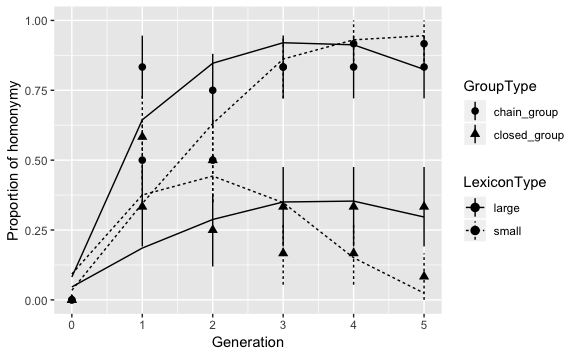

```r
ggplot(df_homonymy, aes(Generation, Word_repetition_binary, shape=GroupType, linetype=LexiconType)) +
  stat_summary(fun.data=mean_se, geom="pointrange") +
  stat_summary(aes(y=fitted(homonymy_second_order_log), linetype=LexiconType),
               fun.y=mean, geom="line") +
  ylab("Proportion of homonymy")
```

```r
dev.print(pdf,'Homonymy Log by Group and Lexicon type - first order model.pdf')
```

# 11 Homonymy (Gen1-5)

Because there’s discontinuity between Generation/Round 0 and 1, redo the analysis in ‘Homonymy’ without Generation/Round 0 (i.e., only Generations 1-5).

## 11.1 Homonymy (Gen1-5): Models

Can’t fit a 3rd order model because there are fewer observations than random effects

```r
homonymy_first_order_1to5 <- lmer(Word_repetition ~
                               ot1*GroupType*LexiconType + (1|Unique_Participant),
                             data=df_homonymy[df_homonymy$Generation != 0, ],
                             control=lmerControl(optimizer = "bobyqa", optCtrl=list(maxfun=1e5)))
homonymy_second_order_1to5 <- lmer(Word_repetition ~
                                (ot1+ot2)*GroupType*LexiconType + (1|Unique_Participant),
                              data=df_homonymy[df_homonymy$Generation != 0, ],
                              control=lmerControl(optimizer = "bobyqa", optCtrl=list(maxfun=1e5)))
summary(homonymy_first_order_1to5)
```

```
Linear mixed model fit by REML. t-tests use Satterthwaite's method [
lmerModLmerTest]
Formula:
Word_repetition ~ ot1 * GroupType * LexiconType + (1 | Unique_Participant)
   Data: df_homonymy[df_homonymy$Generation != 0, ]
Control: lmerControl(optimizer = "bobyqa", optCtrl = list(maxfun = 1e+05))

REML criterion at convergence: -538.6

Scaled residuals:
     Min       1Q   Median       3Q      Max
-2.26218 -0.42304 -0.07362  0.38388  2.49506

Random effects:
 Groups             Name        Variance Std.Dev.
 Unique_Participant (Intercept) 0.006011 0.07753
 Residual                       0.001809 0.04253
Number of obs: 240, groups:  Unique_Participant, 144

Fixed effects:
                              Estimate Std. Error         df t value
(Intercept)                   0.069581   0.009229  96.125742   7.539
ot1                           0.030930   0.013249 197.310275   2.335
GroupType1                    0.036768   0.009229  96.125742   3.984
LexiconType1                 -0.001947   0.009229  96.125742  -0.211
ot1:GroupType1                0.061434   0.013249 197.310275   4.637
ot1:LexiconType1              0.030930   0.013249 197.310275   2.335
GroupType1:LexiconType1       0.006560   0.009229  96.125742   0.711
ot1:GroupType1:LexiconType1  -0.005383   0.013249 197.310275  -0.406
                            Pr(>|t|)
(Intercept)                 2.63e-11 ***
ot1                         0.020568 *
GroupType1                  0.000132 ***
LexiconType1                0.833352
ot1:GroupType1              6.42e-06 ***
ot1:LexiconType1            0.020568 *
GroupType1:LexiconType1     0.478956
ot1:GroupType1:LexiconType1 0.684960
---
Signif. codes:  0 ‘***’ 0.001 ‘**’ 0.01 ‘*’ 0.05 ‘.’ 0.1 ‘ ’ 1

Correlation of Fixed Effects:
            (Intr) ot1    GrpTy1 LxcnT1 ot1:GT1 o1:LT1 GT1:LT
ot1         -0.172
GroupType1  -0.570 -0.107
LexiconTyp1  0.000  0.000  0.000
ot1:GrpTyp1 -0.107  0.624 -0.172  0.000
ot1:LxcnTy1  0.000  0.000  0.000 -0.172  0.000
GrpTyp1:LT1  0.000  0.000  0.000 -0.570  0.000  -0.107
ot1:GT1:LT1  0.000  0.000  0.000 -0.107  0.000   0.624 -0.172
```

```r
summary(homonymy_second_order_1to5)
```

```
Linear mixed model fit by REML. t-tests use Satterthwaite's method [
lmerModLmerTest]
Formula: Word_repetition ~ (ot1 + ot2) * GroupType * LexiconType + (1 |
    Unique_Participant)
   Data: df_homonymy[df_homonymy$Generation != 0, ]
Control: lmerControl(optimizer = "bobyqa", optCtrl = list(maxfun = 1e+05))

REML criterion at convergence: -513.8

Scaled residuals:
     Min       1Q   Median       3Q      Max
-2.08844 -0.46938 -0.09452  0.41061  2.37937

Random effects:
 Groups             Name        Variance Std.Dev.
 Unique_Participant (Intercept) 0.006069 0.07790
 Residual                       0.001827 0.04274
Number of obs: 240, groups:  Unique_Participant, 144

Fixed effects:
                              Estimate Std. Error         df t value
(Intercept)                   0.072678   0.009790 102.368191   7.423
ot1                           0.019823   0.017431 194.408408   1.137
ot2                           0.016224   0.016434 194.408408   0.987
GroupType1                    0.038033   0.009790 102.368191   3.885
LexiconType1                 -0.003479   0.009790 102.368191  -0.355
ot1:GroupType1                0.056897   0.017431 194.408408   3.264
ot2:GroupType1                0.006626   0.016434 194.408408   0.403
ot1:LexiconType1              0.036423   0.017431 194.408408   2.090
ot2:LexiconType1             -0.008023   0.016434 194.408408  -0.488
GroupType1:LexiconType1       0.007246   0.009790 102.368191   0.740
ot1:GroupType1:LexiconType1  -0.007845   0.017431 194.408408  -0.450
ot2:GroupType1:LexiconType1   0.003595   0.016434 194.408408   0.219
                            Pr(>|t|)
(Intercept)                 3.49e-11 ***
ot1                         0.256854
ot2                         0.324779
GroupType1                  0.000182 ***
LexiconType1                0.723060
ot1:GroupType1              0.001298 **
```

[output cut: 19 more lines]

```
GrpTyp1:LT1  0.000  0.000  0.000  0.000 -0.447  0.000   0.000  -0.207  0.200
ot1:GT1:LT1  0.000  0.000  0.000  0.000 -0.207  0.000   0.000   0.624 -0.403
ot2:GT1:LT1  0.000  0.000  0.000  0.000  0.200  0.000   0.000  -0.403  0.624
            GT1:LT o1:GT1:
ot1
ot2
GroupType1
LexiconTyp1
ot1:GrpTyp1
ot2:GrpTyp1
ot1:LxcnTy1
ot2:LxcnTy1
GrpTyp1:LT1
ot1:GT1:LT1 -0.331
ot2:GT1:LT1  0.321 -0.645
```

## 11.2 Homonymy (Gen1-5): Model comparison

```r
homonyms_1to5_model.names <- c("Homonymy first order 1 to 5","Homonymy second order 1 to 5")
homonyms_1to5_summ.table <- do.call(rbind, lapply(list(homonymy_first_order_1to5,homonymy_second_order_1to5), broom::glance))
homonyms_1to5_table.cols <- c("df.residual", "deviance", "AIC")
homonyms_1to5_reported.table <- homonyms_1to5_summ.table[homonyms_1to5_table.cols]
names(homonyms_1to5_reported.table) <- c("Resid. Df", "Resid.Dev", "AIC")
homonyms_1to5_reported.table[['dAIC']] <-  with(homonyms_1to5_reported.table, AIC - min(AIC))
homonyms_1to5_reported.table[['AIC_weight']] <- with(homonyms_1to5_reported.table, exp(- 0.5 * dAIC) / sum(exp(- 0.5 * dAIC)))
homonyms_1to5_reported.table$AIC <- NULL
homonyms_1to5_reported.table$AIC_weight <- round(homonyms_1to5_reported.table$AIC_weight, 2)
homonyms_1to5_reported.table$dAIC <- round(homonyms_1to5_reported.table$dAIC, 1)
homonyms_1to5_reported.table$Resid.Dev <- round(homonyms_1to5_reported.table$Resid.Dev, 2)
row.names(homonyms_1to5_reported.table) <- homonyms_1to5_model.names
```

```
Setting row names on a tibble is deprecated.
```

```r
View(homonyms_1to5_reported.table)
anova(homonymy_first_order_1to5,homonymy_second_order_1to5)
```

```
refitting model(s) with ML (instead of REML)
```

```
Data: df_homonymy[df_homonymy$Generation != 0, ]
Models:
homonymy_first_order_1to5: Word_repetition ~ ot1 * GroupType * LexiconType + (1 | Unique_Participant)
homonymy_second_order_1to5: Word_repetition ~ (ot1 + ot2) * GroupType * LexiconType + (1 |
homonymy_second_order_1to5:     Unique_Participant)
                           Df     AIC     BIC logLik deviance  Chisq Chi Df
homonymy_first_order_1to5  10 -578.15 -543.34 299.08  -598.15
homonymy_second_order_1to5 14 -571.96 -523.23 299.98  -599.96 1.8088      4
                           Pr(>Chisq)
homonymy_first_order_1to5
homonymy_second_order_1to5     0.7709
```

```r
sjPlot::tab_df(homonyms_reported.table,
               file="model comparison homonyms_1to5_.doc")
sjPlot::tab_df(round(coef(summary(homonymy_first_order_1to5)),3),file='homonyms_1to5_fixed_effects.doc')
```

## 11.3 Homonymy (Gen1-5): Plots of model fit

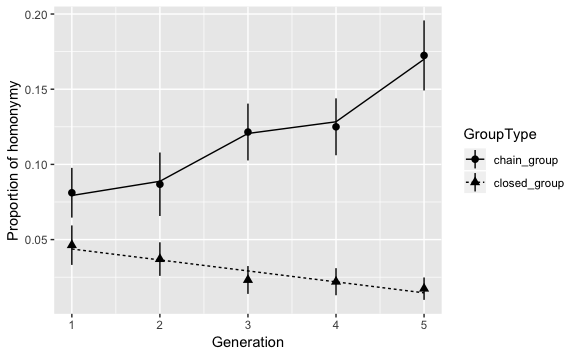

```r
ggplot(df_homonymy[df_homonymy$Generation != 0, ], aes(Generation, Word_repetition, shape=GroupType)) +
  stat_summary(fun.data=mean_se, geom="pointrange") +
  stat_summary(aes(y=fitted(homonymy_first_order_1to5), linetype=GroupType),
               fun.y=mean, geom="line") +
  ylab("Proportion of homonymy")
```

```r
dev.print(pdf,'Homonymy 1to5 by group type - first order model.pdf')
```

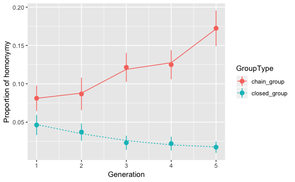

```r
ggplot(df_homonymy[df_homonymy$Generation != 0, ], aes(Generation, Word_repetition, color=GroupType)) +
  stat_summary(fun.data=mean_se, geom="pointrange") +
  stat_summary(aes(y=fitted(homonymy_second_order_1to5), linetype=GroupType),
               fun.y=mean, geom="line") +
  ylab("Proportion of homonymy")
```

```r
dev.print(pdf,'Homonymy 1to5  by group type - second order model.pdf')
```

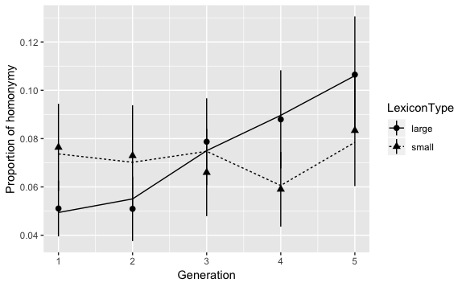

```r
ggplot(df_homonymy[df_homonymy$Generation != 0, ], aes(Generation, Word_repetition, shape=LexiconType)) +
  stat_summary(fun.data=mean_se, geom="pointrange") +
  stat_summary(aes(y=fitted(homonymy_first_order_1to5), linetype=LexiconType),
               fun.y=mean, geom="line") +
  ylab("Proportion of homonymy")
```

```r
dev.print(pdf,'Homonymy 1to5 by lexicon type - first order model.pdf')
```

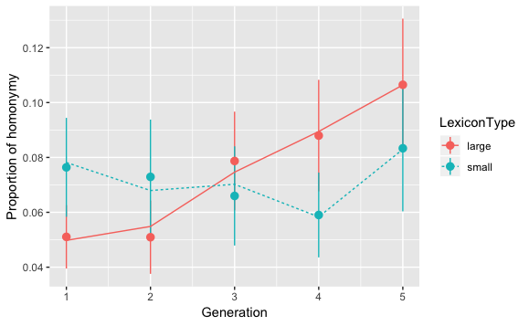

```r
ggplot(df_homonymy[df_homonymy$Generation != 0, ], aes(Generation, Word_repetition, color=LexiconType)) +
  stat_summary(fun.data=mean_se, geom="pointrange") +
  stat_summary(aes(y=fitted(homonymy_second_order_1to5), linetype=LexiconType),
               fun.y=mean, geom="line") +
  ylab("Proportion of homonymy")
```

```r
dev.print(pdf,'Homonymy 1to5  by lexicon type - second order model.pdf')
```

# 12 Homonymy and sound repetition

Two related questions: 1) Is sound repetition more prevelant among homonyms? (i.e., Is sound repetition driven by homonymy?) 2) Do we see the same pattern of sound repetition increase when we look only at non-homonyms?

```r
# This bit of script identifies homonyms in each lexicon
# Identify duplicates within every subset of words
df_u = ddply(df_director, c("GroupType", "LexiconType", "GroupNumber", "Generation", "Unique_language", "Pair", "Unique_Participant"), summarise, dup = duplicated(TypedLabel))
# Paste that information back to the main dateframe
df_u2 = cbind(df_director, df_u$dup)
# List up words that have copies (i.e., homonyms)
homs = unique(subset(df_u2, df_u$dup == 'TRUE'))
# Create variable 'homonym'
df_director = merge(df_director, homs, all.x=TRUE)
colnames(df_director)[52] <- "homonym"
df_director$homonym[is.na(df_director$homonym)] <- 0
# Create a subset without homonyms
NoHoms = subset(df_director, homonym == 0)
```

## 12.1 Impact of homonymy on sound repetition

Is sound repetition more prevelant among homonyms? The analysis shows no effects of homonymy on CVC. So the answer is NO.

```r
CVC_hom_third_order <- glmer(New_Redup_B ~ #maximal random effect structure, up to cubic term
                  (ot1+ot2+ot3) * GroupType * LexiconType * homonym + (1|Unique_Participant) + (1|Meaning),
                  data=df_director, family=binomial,
                  control=glmerControl(optimizer = "bobyqa", optCtrl=list(maxfun=1e5)))
CVC_hom_second_order <- glmer(New_Redup_B ~ #maximal random effect structure, up to quadratic term
                    (ot1+ot2) * GroupType * LexiconType * homonym + (1|Unique_Participant) + (1|Meaning),
                   data=df_director, family=binomial,
                   control=glmerControl(optimizer = "bobyqa", optCtrl=list(maxfun=1e5)))
CVC_hom_first_order <- glmer(New_Redup_B ~ #maximal random effect structure, up to linear term
                    ot1 * GroupType * LexiconType * homonym+ (1|Unique_Participant) + (1|Meaning),
                    data=df_director, family=binomial,
                    control=glmerControl(optimizer = "bobyqa", optCtrl=list(maxfun=1e5)))
summary(CVC_hom_third_order)
```

```
Generalized linear mixed model fit by maximum likelihood (Laplace
  Approximation) [glmerMod]
 Family: binomial  ( logit )
Formula:
New_Redup_B ~ (ot1 + ot2 + ot3) * GroupType * LexiconType * homonym +
    (1 | Unique_Participant) + (1 | Meaning)
   Data: df_director
Control: glmerControl(optimizer = "bobyqa", optCtrl = list(maxfun = 1e+05))

     AIC      BIC   logLik deviance df.resid
  5031.3   5247.7  -2481.6   4963.3     4259

Scaled residuals:
    Min      1Q  Median      3Q     Max
-2.3200 -0.6451 -0.4361  0.8118  4.9045

Random effects:
 Groups             Name        Variance Std.Dev.
 Unique_Participant (Intercept) 0.7452   0.8633
 Meaning            (Intercept) 0.2845   0.5334
Number of obs: 4293, groups:  Unique_Participant, 156; Meaning, 18

Fixed effects:
                                     Estimate Std. Error z value Pr(>|z|)
(Intercept)                         -0.808121   0.161868  -4.992 5.96e-07
ot1                                  0.530514   0.190645   2.783  0.00539
ot2                                  0.059379   0.184687   0.322  0.74782
ot3                                 -0.125553   0.159646  -0.786  0.43161
GroupType1                           0.169374   0.092070   1.840  0.06582
LexiconType1                        -0.049593   0.101573  -0.488  0.62537
homonym                              0.017287   0.111668   0.155  0.87697
ot1:GroupType1                       0.354165   0.149023   2.377  0.01747
ot2:GroupType1                      -0.057817   0.147761  -0.391  0.69558
ot3:GroupType1                      -0.124834   0.140804  -0.887  0.37530
ot1:LexiconType1                    -0.404151   0.190573  -2.121  0.03395
ot2:LexiconType1                     0.141966   0.184710   0.769  0.44214
ot3:LexiconType1                     0.138114   0.159736   0.865  0.38724
GroupType1:LexiconType1              0.023625   0.092056   0.257  0.79746
ot1:homonym                         -0.428702   0.269405  -1.591  0.11154
ot2:homonym                         -0.188312   0.259013  -0.727  0.46720
```

[output cut: 36 more lines]

```
ot1:GroupType1:LexiconType1
ot2:GroupType1:LexiconType1
ot3:GroupType1:LexiconType1
ot1:GroupType1:homonym
ot2:GroupType1:homonym
ot3:GroupType1:homonym
ot1:LexiconType1:homonym            .
ot2:LexiconType1:homonym
ot3:LexiconType1:homonym
GroupType1:LexiconType1:homonym
ot1:GroupType1:LexiconType1:homonym
ot2:GroupType1:LexiconType1:homonym
ot3:GroupType1:LexiconType1:homonym
---
Signif. codes:  0 ‘***’ 0.001 ‘**’ 0.01 ‘*’ 0.05 ‘.’ 0.1 ‘ ’ 1
```

```
Correlation matrix not shown by default, as p = 32 > 12.
Use print(x, correlation=TRUE)  or
    vcov(x)        if you need it
```

```r
summary(CVC_hom_second_order)
```

```
Generalized linear mixed model fit by maximum likelihood (Laplace
  Approximation) [glmerMod]
 Family: binomial  ( logit )
Formula: New_Redup_B ~ (ot1 + ot2) * GroupType * LexiconType * homonym +
    (1 | Unique_Participant) + (1 | Meaning)
   Data: df_director
Control: glmerControl(optimizer = "bobyqa", optCtrl = list(maxfun = 1e+05))

     AIC      BIC   logLik deviance df.resid
  5019.5   5184.9  -2483.7   4967.5     4267

Scaled residuals:
    Min      1Q  Median      3Q     Max
-2.4627 -0.6439 -0.4370  0.8098  4.9419

Random effects:
 Groups             Name        Variance Std.Dev.
 Unique_Participant (Intercept) 0.7694   0.8771
 Meaning            (Intercept) 0.2838   0.5327
Number of obs: 4293, groups:  Unique_Participant, 156; Meaning, 18

Fixed effects:
                                     Estimate Std. Error z value Pr(>|z|)
(Intercept)                         -0.822339   0.161606  -5.089 3.61e-07
ot1                                  0.532049   0.169180   3.145  0.00166
ot2                                  0.054258   0.163211   0.332  0.73956
GroupType1                           0.183866   0.089818   2.047  0.04065
LexiconType1                        -0.049034   0.101257  -0.484  0.62821
homonym                              0.012110   0.107987   0.112  0.91071
ot1:GroupType1                       0.354700   0.146312   2.424  0.01534
ot2:GroupType1                      -0.066338   0.144222  -0.460  0.64554
ot1:LexiconType1                    -0.436948   0.169214  -2.582  0.00982
ot2:LexiconType1                     0.183205   0.163203   1.123  0.26162
GroupType1:LexiconType1              0.032274   0.089832   0.359  0.71940
ot1:homonym                         -0.395407   0.267076  -1.481  0.13874
ot2:homonym                         -0.191363   0.253039  -0.756  0.44949
GroupType1:homonym                   0.021833   0.114595   0.191  0.84890
LexiconType1:homonym                 0.191095   0.108050   1.769  0.07696
ot1:GroupType1:LexiconType1         -0.075072   0.146296  -0.513  0.60785
ot2:GroupType1:LexiconType1          0.063014   0.144094   0.437  0.66189
```

[output cut: 19 more lines]

```
ot1:homonym
ot2:homonym
GroupType1:homonym
LexiconType1:homonym                .
ot1:GroupType1:LexiconType1
ot2:GroupType1:LexiconType1
ot1:GroupType1:homonym
ot2:GroupType1:homonym
ot1:LexiconType1:homonym
ot2:LexiconType1:homonym
GroupType1:LexiconType1:homonym
ot1:GroupType1:LexiconType1:homonym
ot2:GroupType1:LexiconType1:homonym
---
Signif. codes:  0 ‘***’ 0.001 ‘**’ 0.01 ‘*’ 0.05 ‘.’ 0.1 ‘ ’ 1
```

```
Correlation matrix not shown by default, as p = 24 > 12.
Use print(x, correlation=TRUE)  or
    vcov(x)        if you need it
```

```r
summary(CVC_hom_first_order)
```

```
Generalized linear mixed model fit by maximum likelihood (Laplace
  Approximation) [glmerMod]
 Family: binomial  ( logit )
Formula: New_Redup_B ~ ot1 * GroupType * LexiconType * homonym + (1 |
    Unique_Participant) + (1 | Meaning)
   Data: df_director
Control: glmerControl(optimizer = "bobyqa", optCtrl = list(maxfun = 1e+05))

     AIC      BIC   logLik deviance df.resid
  5007.8   5122.3  -2485.9   4971.8     4275

Scaled residuals:
    Min      1Q  Median      3Q     Max
-2.0930 -0.6449 -0.4398  0.8119  4.8887

Random effects:
 Groups             Name        Variance Std.Dev.
 Unique_Participant (Intercept) 0.7811   0.8838
 Meaning            (Intercept) 0.2809   0.5300
Number of obs: 4293, groups:  Unique_Participant, 156; Meaning, 18

Fixed effects:
                                     Estimate Std. Error z value Pr(>|z|)
(Intercept)                         -0.814540   0.159732  -5.099 3.41e-07
ot1                                  0.566906   0.150954   3.755 0.000173
GroupType1                           0.169273   0.085254   1.986 0.047088
LexiconType1                        -0.043873   0.099073  -0.443 0.657881
homonym                             -0.006704   0.106605  -0.063 0.949856
ot1:GroupType1                       0.344893   0.141388   2.439 0.014714
ot1:LexiconType1                    -0.338426   0.150828  -2.244 0.024846
GroupType1:LexiconType1             -0.001813   0.085254  -0.021 0.983030
ot1:homonym                         -0.313368   0.250258  -1.252 0.210504
GroupType1:homonym                   0.009150   0.112178   0.082 0.934989
LexiconType1:homonym                 0.161239   0.106657   1.512 0.130597
ot1:GroupType1:LexiconType1         -0.049182   0.141349  -0.348 0.727882
ot1:GroupType1:homonym              -0.253993   0.286781  -0.886 0.375796
ot1:LexiconType1:homonym             0.431257   0.250513   1.721 0.085161
GroupType1:LexiconType1:homonym      0.085663   0.112201   0.763 0.445179
ot1:GroupType1:LexiconType1:homonym  0.322176   0.286629   1.124 0.261005

(Intercept)                         ***
ot1                                 ***
GroupType1                          *
LexiconType1
homonym
ot1:GroupType1                      *
ot1:LexiconType1                    *
GroupType1:LexiconType1
ot1:homonym
GroupType1:homonym
LexiconType1:homonym
ot1:GroupType1:LexiconType1
ot1:GroupType1:homonym
ot1:LexiconType1:homonym            .
GroupType1:LexiconType1:homonym
ot1:GroupType1:LexiconType1:homonym
---
Signif. codes:  0 ‘***’ 0.001 ‘**’ 0.01 ‘*’ 0.05 ‘.’ 0.1 ‘ ’ 1
```

```
Correlation matrix not shown by default, as p = 16 > 12.
Use print(x, correlation=TRUE)  or
    vcov(x)        if you need it
```

```r
CVC_hom_model.names <- c("CVC_hom first order","CVC_hom second order","CVC_hom third order")
CVC_hom_summ.table <- do.call(rbind, lapply(list(CVC_hom_first_order,CVC_hom_second_order,CVC_hom_third_order), broom::glance))
CVC_hom_table.cols <- c("df.residual", "deviance", "AIC")
CVC_hom_reported.table <- CVC_hom_summ.table[CVC_hom_table.cols]
names(CVC_hom_reported.table) <- c("Resid.Df", "Resid.Dev", "AIC")
CVC_hom_reported.table[['dAIC']] <-  with(CVC_hom_reported.table, AIC - min(AIC))
CVC_hom_reported.table[['AIC_weight']] <- with(CVC_hom_reported.table, exp(- 0.5 * dAIC) / sum(exp(- 0.5 * dAIC)))
CVC_hom_reported.table$AIC <- NULL
CVC_hom_reported.table$AIC_weight <- round(CVC_hom_reported.table$AIC_weight, 2)
CVC_hom_reported.table$dAIC <- round(CVC_hom_reported.table$dAIC, 1)
CVC_hom_reported.table$Resid.Dev <- round(CVC_hom_reported.table$Resid.Dev, 2)
row.names(CVC_hom_reported.table) <- CVC_hom_model.names
```

```
Setting row names on a tibble is deprecated.
```

```r
View(CVC_hom_reported.table)
sjPlot::tab_df(CVC_hom_reported.table,
       file="model comparison CVC_hom.doc")
```

## 12.2 Sound repetition among non-homonyms

Here, an anlaysis is run using only words that don’t have any homonyms. We get pretty much the same results as the analysis with all words. So sound repetition increases regardless of homonymy.

```r
CVC_NH_third_order <- glmer(New_Redup_B ~ #maximal random effect structure, up to cubic term
                  (ot1+ot2+ot3) * GroupType * LexiconType + (1|Unique_Participant) + (1|Meaning),
                  data=df_director[df_director$homonym == 0, ], family=binomial,
                  control=glmerControl(optimizer = "bobyqa", optCtrl=list(maxfun=1e5)))
CVC_NH_second_order <- glmer(New_Redup_B ~ #maximal random effect structure, up to quadratic term
                    (ot1+ot2) * GroupType * LexiconType + (1|Unique_Participant) + (1|Meaning),
                   data=df_director[df_director$homonym == 0, ], family=binomial,
                   control=glmerControl(optimizer = "bobyqa", optCtrl=list(maxfun=1e5)))
CVC_NH_first_order <- glmer(New_Redup_B ~ #maximal random effect structure, up to linear term
                    ot1 * GroupType * LexiconType + (1|Unique_Participant) + (1|Meaning),
                    data=df_director[df_director$homonym == 0, ], family=binomial,
                    control=glmerControl(optimizer = "bobyqa", optCtrl=list(maxfun=1e5)))
summary(CVC_NH_third_order)
```

```
Generalized linear mixed model fit by maximum likelihood (Laplace
  Approximation) [glmerMod]
 Family: binomial  ( logit )
Formula: New_Redup_B ~ (ot1 + ot2 + ot3) * GroupType * LexiconType + (1 |
    Unique_Participant) + (1 | Meaning)
   Data: df_director[df_director$homonym == 0, ]
Control: glmerControl(optimizer = "bobyqa", optCtrl = list(maxfun = 1e+05))

     AIC      BIC   logLik deviance df.resid
  3947.7   4057.9  -1955.8   3911.7     3358

Scaled residuals:
    Min      1Q  Median      3Q     Max
-2.1583 -0.6286 -0.4412  0.8176  4.0566

Random effects:
 Groups             Name        Variance Std.Dev.
 Unique_Participant (Intercept) 0.7569   0.8700
 Meaning            (Intercept) 0.2940   0.5422
Number of obs: 3376, groups:  Unique_Participant, 154; Meaning, 18

Fixed effects:
                            Estimate Std. Error z value Pr(>|z|)
(Intercept)                 -0.81889    0.16432  -4.984 6.24e-07 ***
ot1                          0.55213    0.19351   2.853  0.00433 **
ot2                          0.04084    0.18702   0.218  0.82712
ot3                         -0.12438    0.16215  -0.767  0.44303
GroupType1                   0.16855    0.09369   1.799  0.07202 .
LexiconType1                -0.04253    0.10278  -0.414  0.67900
ot1:GroupType1               0.34547    0.15358   2.249  0.02449 *
ot2:GroupType1              -0.05535    0.15167  -0.365  0.71514
ot3:GroupType1              -0.13376    0.14404  -0.929  0.35309
ot1:LexiconType1            -0.41155    0.19331  -2.129  0.03326 *
ot2:LexiconType1             0.14179    0.18702   0.758  0.44836
ot3:LexiconType1             0.17699    0.16215   1.092  0.27505
GroupType1:LexiconType1      0.01105    0.09367   0.118  0.90609
ot1:GroupType1:LexiconType1 -0.09222    0.15349  -0.601  0.54798
ot2:GroupType1:LexiconType1  0.07024    0.15146   0.464  0.64281
ot3:GroupType1:LexiconType1  0.06170    0.14375   0.429  0.66774
---
Signif. codes:  0 ‘***’ 0.001 ‘**’ 0.01 ‘*’ 0.05 ‘.’ 0.1 ‘ ’ 1
```

```
Correlation matrix not shown by default, as p = 16 > 12.
Use print(x, correlation=TRUE)  or
    vcov(x)        if you need it
```

```r
summary(CVC_NH_second_order)
```

```
Generalized linear mixed model fit by maximum likelihood (Laplace
  Approximation) [glmerMod]
 Family: binomial  ( logit )
Formula:
New_Redup_B ~ (ot1 + ot2) * GroupType * LexiconType + (1 | Unique_Participant) +
    (1 | Meaning)
   Data: df_director[df_director$homonym == 0, ]
Control: glmerControl(optimizer = "bobyqa", optCtrl = list(maxfun = 1e+05))

     AIC      BIC   logLik deviance df.resid
  3942.0   4027.8  -1957.0   3914.0     3362

Scaled residuals:
    Min      1Q  Median      3Q     Max
-2.1585 -0.6324 -0.4414  0.8190  4.0866

Random effects:
 Groups             Name        Variance Std.Dev.
 Unique_Participant (Intercept) 0.7671   0.8758
 Meaning            (Intercept) 0.2944   0.5426
Number of obs: 3376, groups:  Unique_Participant, 154; Meaning, 18

Fixed effects:
                            Estimate Std. Error z value Pr(>|z|)
(Intercept)                 -0.83447    0.16392  -5.091 3.57e-07 ***
ot1                          0.56774    0.17316   3.279  0.00104 **
ot2                          0.02413    0.16592   0.145  0.88438
GroupType1                   0.17729    0.09219   1.923  0.05447 .
LexiconType1                -0.03698    0.10190  -0.363  0.71669
ot1:GroupType1               0.34903    0.14977   2.330  0.01978 *
ot2:GroupType1              -0.06655    0.14699  -0.453  0.65069
ot1:LexiconType1            -0.48696    0.17319  -2.812  0.00493 **
ot2:LexiconType1             0.21926    0.16597   1.321  0.18647
GroupType1:LexiconType1      0.02109    0.09219   0.229  0.81903
ot1:GroupType1:LexiconType1 -0.07581    0.14970  -0.506  0.61257
ot2:GroupType1:LexiconType1  0.05613    0.14683   0.382  0.70226
---
Signif. codes:  0 ‘***’ 0.001 ‘**’ 0.01 ‘*’ 0.05 ‘.’ 0.1 ‘ ’ 1

Correlation of Fixed Effects:
```

[output cut: 9 more lines]

```
GrpTyp1:LT1  0.020  0.031 -0.010 -0.098 -0.467  0.070  -0.041  -0.050  0.051
ot1:GT1:LT1 -0.006  0.047 -0.045  0.070 -0.184 -0.158   0.089   0.252  0.058
ot2:GT1:LT1  0.018 -0.043  0.022 -0.041  0.170  0.089  -0.153   0.060  0.256
            GT1:LT o1:GT1:
ot1
ot2
GroupType1
LexiconTyp1
ot1:GrpTyp1
ot2:GrpTyp1
ot1:LxcnTy1
ot2:LxcnTy1
GrpTyp1:LT1
ot1:GT1:LT1  0.132
ot2:GT1:LT1 -0.156 -0.232
```

```r
summary(CVC_NH_first_order)
```

```
Generalized linear mixed model fit by maximum likelihood (Laplace
  Approximation) [glmerMod]
 Family: binomial  ( logit )
Formula:
New_Redup_B ~ ot1 * GroupType * LexiconType + (1 | Unique_Participant) +
    (1 | Meaning)
   Data: df_director[df_director$homonym == 0, ]
Control: glmerControl(optimizer = "bobyqa", optCtrl = list(maxfun = 1e+05))

     AIC      BIC   logLik deviance df.resid
  3936.2   3997.4  -1958.1   3916.2     3366

Scaled residuals:
    Min      1Q  Median      3Q     Max
-2.1879 -0.6298 -0.4443  0.8141  4.0565

Random effects:
 Groups             Name        Variance Std.Dev.
 Unique_Participant (Intercept) 0.7765   0.8812
 Meaning            (Intercept) 0.2940   0.5422
Number of obs: 3376, groups:  Unique_Participant, 154; Meaning, 18

Fixed effects:
                            Estimate Std. Error z value Pr(>|z|)
(Intercept)                 -0.82883    0.16313  -5.081 3.76e-07 ***
ot1                          0.59170    0.15573   3.800 0.000145 ***
GroupType1                   0.16758    0.09083   1.845 0.065048 .
LexiconType1                -0.04619    0.10063  -0.459 0.646240
ot1:GroupType1               0.33463    0.14472   2.312 0.020759 *
ot1:LexiconType1            -0.39614    0.15553  -2.547 0.010865 *
GroupType1:LexiconType1      0.01167    0.09084   0.128 0.897811
ot1:GroupType1:LexiconType1 -0.07951    0.14466  -0.550 0.582574
---
Signif. codes:  0 ‘***’ 0.001 ‘**’ 0.01 ‘*’ 0.05 ‘.’ 0.1 ‘ ’ 1

Correlation of Fixed Effects:
            (Intr) ot1    GrpTy1 LxcnT1 ot1:GT1 o1:LT1 GT1:LT
ot1         -0.082
GroupType1  -0.285  0.002
LexiconTyp1 -0.061  0.018  0.054
ot1:GrpTyp1 -0.101  0.372  0.096 -0.011
ot1:LxcnTy1  0.014 -0.090  0.034 -0.131  0.009
GrpTyp1:LT1  0.031  0.035 -0.123 -0.458  0.076   0.001
ot1:GT1:LT1 -0.006  0.009  0.076 -0.162 -0.118   0.372  0.096
```

```r
CVC_NH_model.names <- c("CVC_NH first order","CVC_NH second order","CVC_NH third order")
CVC_NH_summ.table <- do.call(rbind, lapply(list(CVC_NH_first_order,CVC_NH_second_order,CVC_NH_third_order), broom::glance))
CVC_NH_table.cols <- c("df.residual", "deviance", "AIC")
CVC_NH_reported.table <- CVC_NH_summ.table[CVC_NH_table.cols]
names(CVC_NH_reported.table) <- c("Resid.Df", "Resid.Dev", "AIC")
CVC_NH_reported.table[['dAIC']] <-  with(CVC_NH_reported.table, AIC - min(AIC))
CVC_NH_reported.table[['AIC_weight']] <- with(CVC_NH_reported.table, exp(- 0.5 * dAIC) / sum(exp(- 0.5 * dAIC)))
CVC_NH_reported.table$AIC <- NULL
CVC_NH_reported.table$AIC_weight <- round(CVC_NH_reported.table$AIC_weight, 2)
CVC_NH_reported.table$dAIC <- round(CVC_NH_reported.table$dAIC, 1)
CVC_NH_reported.table$Resid.Dev <- round(CVC_NH_reported.table$Resid.Dev, 2)
row.names(CVC_NH_reported.table) <- CVC_NH_model.names
```

```
Setting row names on a tibble is deprecated.
```

```r
View(CVC_NH_reported.table)
sjPlot::tab_df(CVC_NH_reported.table,
       file="model comparison CVC_NH.doc")
```

Here’s a plot showing the proportion of CVC repetition in non-homonyms

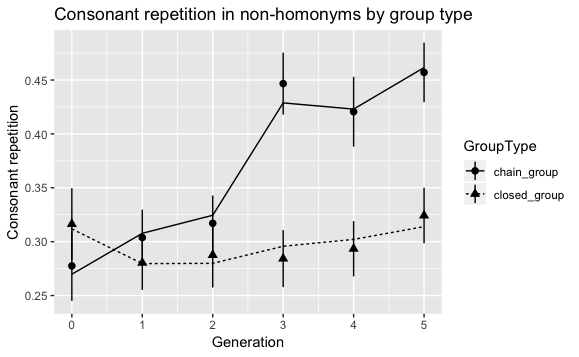

```r
ggplot(NoHoms, aes(Generation, New_Redup_B, shape=GroupType)) +
  stat_summary(fun.data=mean_se, geom="pointrange") +
  stat_summary(aes(y=fitted(CVC_NH_first_order), linetype=GroupType),
               fun.y=mean, geom="line") +
  ylab("Consonant repetition")+
  ggtitle('Consonant repetition in non-homonyms by group type')
```

```r
dev.print(pdf, 'Consonant repetition in non-homonyms by group type - first order model.pdf')
```

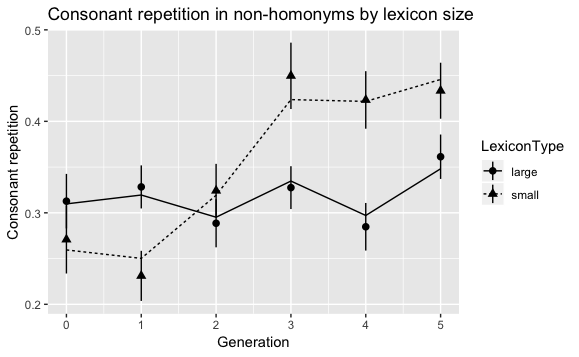

```r
ggplot(NoHoms, aes(Generation, New_Redup_B, shape=LexiconType)) +
  stat_summary(fun.data=mean_se, geom="pointrange") +
  stat_summary(aes(y=fitted(CVC_NH_first_order), linetype=LexiconType),
               fun.y=mean, geom="line") +
  ylab("Consonant repetition")+
  ggtitle('Consonant repetition in non-homonyms by lexicon size')
```

```r
dev.print(pdf, 'Consonant repetition in non-homonyms by lexicon size - first order model.pdf')
```

# 13 Word length and sound repetition

A query raised by Jenny is whether the repetition effects could be driven by word length - so longer words will be more likely to contain repetitions and words get longer in the chains than in the closed groups.

As the analysis below shows, there’s obviously a clear association between word length and sound repetition, although the direction of the causality could be rep -> length.

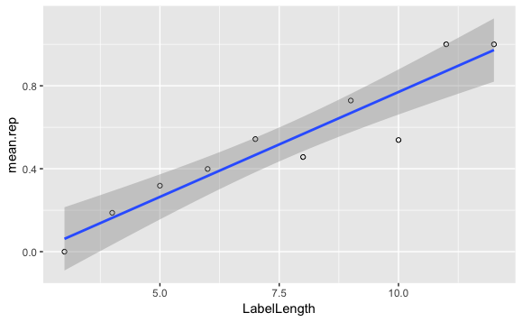

```r
df_director_generations_1_to_5$LabelLength = nchar(as.character(df_director_generations_1_to_5$TypedLabel))
RepXLength = ddply(df_director_generations_1_to_5, c("LabelLength"), summarise, mean.rep = mean(New_Redup_B))
ggplot(RepXLength, aes(x=LabelLength, y=mean.rep)) +
    geom_point(shape=1) +
    geom_smooth(method=lm)
```

```r
summary(lm(LabelLength ~ mean.rep, data=RepXLength))
```

```
Call:
lm(formula = LabelLength ~ mean.rep, data = RepXLength)

Residuals:
    Min      1Q  Median      3Q     Max
-0.7622 -0.6932 -0.4123  0.1943  2.3114

Coefficients:
            Estimate Std. Error t value Pr(>|t|)
(Intercept)   2.9359     0.6501   4.516  0.00196 **
mean.rep      8.8263     1.0806   8.168 3.76e-05 ***
---
Signif. codes:  0 ‘***’ 0.001 ‘**’ 0.01 ‘*’ 0.05 ‘.’ 0.1 ‘ ’ 1

Residual standard error: 1.051 on 8 degrees of freedom
Multiple R-squared:  0.8929,    Adjusted R-squared:  0.8795
F-statistic: 66.71 on 1 and 8 DF,  p-value: 3.759e-05
```

So, can this explain why we find a GroupType or LexiconSize effect on repetition? Here’s a figure showing the average label length by GroupType and LexiconSize, followed by a set of GCA analyses. The linear analysis (best fit) shows that label length increases over time, but this increase doesn’t interact with GroupType or LexiconSize.

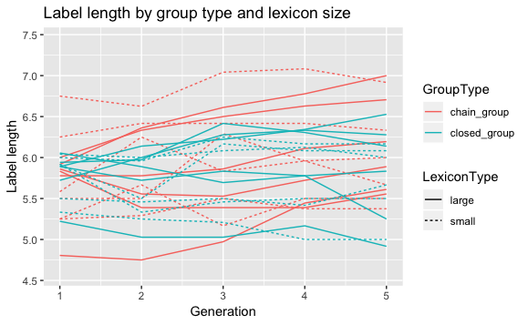

```r
df_director_plot$LabelLength = nchar(as.character(df_director$TypedLabel))
ggplot(df_director_plot, aes(Generation, LabelLength, group = group_id, colour=GroupType, linetype=LexiconType)) +
  stat_summary(fun.data=mean_se, geom="line") +
  ylab("Label length")+
  ggtitle('Label length by group type and lexicon size')
```

```r
dev.print(pdf, 'Label length by group and lexicon.pdf')
```

```r
LabelLength_third_order <- lmer(LabelLength ~ #maximal random effect structure, up to cubic term
                  (ot1+ot2+ot3) * GroupType * LexiconType + (1|Unique_Participant) + (1|Meaning),
                  data=df_director_plot,
                  control=lmerControl(optimizer = "bobyqa", optCtrl=list(maxfun=1e5)))
LabelLength_second_order <- lmer(LabelLength ~ #maximal random effect structure, up to quadratic term
                    (ot1+ot2) * GroupType * LexiconType + (1|Unique_Participant) + (1|Meaning),
                   data=df_director_plot,
                   control=lmerControl(optimizer = "bobyqa", optCtrl=list(maxfun=1e5)))
LabelLength_first_order <- lmer(LabelLength ~ #maximal random effect structure, up to linear term
                    ot1 * GroupType * LexiconType + (1|Unique_Participant) + (1|Meaning),
                    data=df_director_plot,
                    control=lmerControl(optimizer = "bobyqa", optCtrl=list(maxfun=1e5)))
summary(LabelLength_third_order)
```

```
Linear mixed model fit by REML. t-tests use Satterthwaite's method [
lmerModLmerTest]
Formula: LabelLength ~ (ot1 + ot2 + ot3) * GroupType * LexiconType + (1 |
    Unique_Participant) + (1 | Meaning)
   Data: df_director_plot
Control: lmerControl(optimizer = "bobyqa", optCtrl = list(maxfun = 1e+05))

REML criterion at convergence: 13516.3

Scaled residuals:
    Min      1Q  Median      3Q     Max
-2.2978 -0.9185  0.0555  0.7996  4.3738

Random effects:
 Groups             Name        Variance Std.Dev.
 Unique_Participant (Intercept) 0.1601   0.4001
 Meaning            (Intercept) 0.1472   0.3836
 Residual                       2.3832   1.5437
Number of obs: 3593, groups:  Unique_Participant, 144; Meaning, 18

Fixed effects:
                             Estimate Std. Error        df t value Pr(>|t|)
(Intercept)                   5.81076    0.12002  42.70091  48.415   <2e-16
ot1                           0.08351    0.22632 382.78778   0.369    0.712
ot2                           0.09782    0.20861 382.45038   0.469    0.639
ot3                          -0.12489    0.15179 382.47872  -0.823    0.411
GroupType1                    0.01926    0.07815 159.29109   0.246    0.806
LexiconType1                  0.07036    0.07894 165.71974   0.891    0.374
ot1:GroupType1                0.24891    0.22632 382.78755   1.100    0.272
ot2:GroupType1               -0.09212    0.20861 382.45109  -0.442    0.659
ot3:GroupType1                0.07308    0.15179 382.47881   0.481    0.630
ot1:LexiconType1              0.02873    0.22632 382.78778   0.127    0.899
ot2:LexiconType1              0.08342    0.20861 382.45038   0.400    0.689
ot3:LexiconType1             -0.02707    0.15179 382.47872  -0.178    0.859
GroupType1:LexiconType1      -0.01431    0.07815 159.29109  -0.183    0.855
ot1:GroupType1:LexiconType1  -0.10883    0.22632 382.78755  -0.481    0.631
ot2:GroupType1:LexiconType1   0.21399    0.20861 382.45109   1.026    0.306
ot3:GroupType1:LexiconType1  -0.03872    0.15179 382.47881  -0.255    0.799

(Intercept)                 ***
ot1
ot2
ot3
GroupType1
LexiconType1
ot1:GroupType1
ot2:GroupType1
ot3:GroupType1
ot1:LexiconType1
ot2:LexiconType1
ot3:LexiconType1
GroupType1:LexiconType1
ot1:GroupType1:LexiconType1
ot2:GroupType1:LexiconType1
ot3:GroupType1:LexiconType1
---
Signif. codes:  0 ‘***’ 0.001 ‘**’ 0.01 ‘*’ 0.05 ‘.’ 0.1 ‘ ’ 1
```

```
Correlation matrix not shown by default, as p = 16 > 12.
Use print(x, correlation=TRUE)  or
    vcov(x)        if you need it
```

```r
summary(LabelLength_second_order)
```

```
Linear mixed model fit by REML. t-tests use Satterthwaite's method [
lmerModLmerTest]
Formula:
LabelLength ~ (ot1 + ot2) * GroupType * LexiconType + (1 | Unique_Participant) +
    (1 | Meaning)
   Data: df_director_plot
Control: lmerControl(optimizer = "bobyqa", optCtrl = list(maxfun = 1e+05))

REML criterion at convergence: 13509.7

Scaled residuals:
    Min      1Q  Median      3Q     Max
-2.3002 -0.9184  0.0567  0.7941  4.3754

Random effects:
 Groups             Name        Variance Std.Dev.
 Unique_Participant (Intercept) 0.1566   0.3957
 Meaning            (Intercept) 0.1472   0.3836
 Residual                       2.3825   1.5435
Number of obs: 3593, groups:  Unique_Participant, 144; Meaning, 18

Fixed effects:
                              Estimate Std. Error         df t value
(Intercept)                   5.767291   0.107556  28.241490  53.621
ot1                           0.239329   0.123528 393.791328   1.937
ot2                          -0.044399   0.116430 393.374745  -0.381
GroupType1                    0.044712   0.057188  95.010423   0.782
LexiconType1                  0.060894   0.058245 102.250965   1.045
ot1:GroupType1                0.157709   0.123528 393.790878   1.277
ot2:GroupType1               -0.008871   0.116430 393.375363  -0.076
ot1:LexiconType1              0.062535   0.123528 393.791328   0.506
ot2:LexiconType1              0.052586   0.116430 393.374745   0.452
GroupType1:LexiconType1      -0.027742   0.057188  95.010423  -0.485
ot1:GroupType1:LexiconType1  -0.060586   0.123528 393.790878  -0.490
ot2:GroupType1:LexiconType1   0.169946   0.116430 393.375363   1.460
                            Pr(>|t|)
(Intercept)                   <2e-16 ***
ot1                           0.0534 .
ot2                           0.7032
GroupType1                    0.4363
```

[output cut: 21 more lines]

```
GrpTyp1:LT1  0.000  0.000  0.000 -0.067 -0.332  0.054  -0.052  -0.128  0.125
ot1:GT1:LT1  0.000  0.000  0.000  0.054 -0.126 -0.134   0.087   0.320 -0.207
ot2:GT1:LT1  0.000  0.000  0.000 -0.052  0.122  0.087  -0.135  -0.207  0.321
            GT1:LT o1:GT1:
ot1
ot2
GroupType1
LexiconTyp1
ot1:GrpTyp1
ot2:GrpTyp1
ot1:LxcnTy1
ot2:LxcnTy1
GrpTyp1:LT1
ot1:GT1:LT1 -0.402
ot2:GT1:LT1  0.389 -0.646
```

```r
summary(LabelLength_first_order)
```

```
Linear mixed model fit by REML. t-tests use Satterthwaite's method [
lmerModLmerTest]
Formula:
LabelLength ~ ot1 * GroupType * LexiconType + (1 | Unique_Participant) +
    (1 | Meaning)
   Data: df_director_plot
Control: lmerControl(optimizer = "bobyqa", optCtrl = list(maxfun = 1e+05))

REML criterion at convergence: 13502

Scaled residuals:
    Min      1Q  Median      3Q     Max
-2.2831 -0.9189  0.0570  0.7992  4.3589

Random effects:
 Groups             Name        Variance Std.Dev.
 Unique_Participant (Intercept) 0.1555   0.3943
 Meaning            (Intercept) 0.1471   0.3836
 Residual                       2.3818   1.5433
Number of obs: 3593, groups:  Unique_Participant, 144; Meaning, 18

Fixed effects:
                             Estimate Std. Error        df t value Pr(>|t|)
(Intercept)                   5.77577    0.10515  25.90582  54.929   <2e-16
ot1                           0.20880    0.09422 400.08135   2.216   0.0272
GroupType1                    0.04636    0.05254  80.49492   0.882   0.3802
LexiconType1                  0.05089    0.05369  87.80078   0.948   0.3458
ot1:GroupType1                0.15172    0.09422 400.08027   1.610   0.1081
ot1:LexiconType1              0.09840    0.09422 400.08135   1.044   0.2969
GroupType1:LexiconType1      -0.06024    0.05254  80.49492  -1.147   0.2550
ot1:GroupType1:LexiconType1   0.05586    0.09422 400.08027   0.593   0.5536

(Intercept)                 ***
ot1                         *
GroupType1
LexiconType1
ot1:GroupType1
ot1:LexiconType1
GroupType1:LexiconType1
ot1:GroupType1:LexiconType1
---
Signif. codes:  0 ‘***’ 0.001 ‘**’ 0.01 ‘*’ 0.05 ‘.’ 0.1 ‘ ’ 1

Correlation of Fixed Effects:
            (Intr) ot1    GrpTy1 LxcnT1 ot1:GT1 o1:LT1 GT1:LT
ot1         -0.107
GroupType1  -0.227 -0.068
LexiconTyp1 -0.049  0.028  0.000
ot1:GrpTyp1 -0.034  0.320 -0.214  0.000
ot1:LxcnTy1  0.015 -0.134  0.000 -0.210  0.000
GrpTyp1:LT1  0.000  0.000 -0.056 -0.445  0.029  -0.068
ot1:GT1:LT1  0.000  0.000  0.029 -0.067 -0.134   0.320 -0.214
```

```r
LabelLength_model.names <- c("LabelLength first order","LabelLength second order","LabelLength third order")
LabelLength_summ.table <- do.call(rbind, lapply(list(LabelLength_first_order,LabelLength_second_order,LabelLength_third_order), broom::glance))
LabelLength_table.cols <- c("df.residual", "deviance", "AIC")
LabelLength_reported.table <- LabelLength_summ.table[LabelLength_table.cols]
names(LabelLength_reported.table) <- c("Resid.Df", "Resid.Dev", "AIC")
LabelLength_reported.table[['dAIC']] <-  with(LabelLength_reported.table, AIC - min(AIC))
LabelLength_reported.table[['AIC_weight']] <- with(LabelLength_reported.table, exp(- 0.5 * dAIC) / sum(exp(- 0.5 * dAIC)))
LabelLength_reported.table$AIC <- NULL
LabelLength_reported.table$AIC_weight <- round(LabelLength_reported.table$AIC_weight, 2)
LabelLength_reported.table$dAIC <- round(LabelLength_reported.table$dAIC, 1)
LabelLength_reported.table$Resid.Dev <- round(LabelLength_reported.table$Resid.Dev, 2)
row.names(LabelLength_reported.table) <- LabelLength_model.names
```

```
Setting row names on a tibble is deprecated.
```

```r
View(LabelLength_reported.table)
sjPlot::tab_df(LabelLength_reported.table,
       file="model comparison LabelLength.doc")
```

```r
CVC_LabelLength_first_order <- glmer(New_Redup_B ~ #maximal random effect structure, up to linear term
                    ot1 * GroupType * LexiconType + LabelLength + (1|Unique_Participant) + (1|Meaning),
                    data=df_director_plot, family=binomial,
                    control=glmerControl(optimizer = "bobyqa", optCtrl=list(maxfun=1e5)))
summary(CVC_LabelLength_first_order)
```

```
Generalized linear mixed model fit by maximum likelihood (Laplace
  Approximation) [glmerMod]
 Family: binomial  ( logit )
Formula: New_Redup_B ~ ot1 * GroupType * LexiconType + LabelLength + (1 |
    Unique_Participant) + (1 | Meaning)
   Data: df_director_plot
Control: glmerControl(optimizer = "bobyqa", optCtrl = list(maxfun = 1e+05))

     AIC      BIC   logLik deviance df.resid
  3989.7   4057.7  -1983.8   3967.7     3582

Scaled residuals:
    Min      1Q  Median      3Q     Max
-2.7899 -0.6254 -0.3697  0.7177  3.9017

Random effects:
 Groups             Name        Variance Std.Dev.
 Unique_Participant (Intercept) 0.8765   0.9362
 Meaning            (Intercept) 0.2977   0.5456
Number of obs: 3593, groups:  Unique_Participant, 144; Meaning, 18

Fixed effects:
                            Estimate Std. Error z value Pr(>|z|)
(Intercept)                 -2.94850    0.23698 -12.442  < 2e-16 ***
ot1                          0.52922    0.17541   3.017  0.00255 **
GroupType1                   0.18926    0.11488   1.647  0.09947 .
LexiconType1                -0.04797    0.11606  -0.413  0.67936
LabelLength                  0.35762    0.02676  13.363  < 2e-16 ***
ot1:GroupType1               0.31927    0.17535   1.821  0.06865 .
ot1:LexiconType1            -0.35218    0.17530  -2.009  0.04454 *
GroupType1:LexiconType1      0.04995    0.11486   0.435  0.66364
ot1:GroupType1:LexiconType1 -0.04625    0.17522  -0.264  0.79182
---
Signif. codes:  0 ‘***’ 0.001 ‘**’ 0.01 ‘*’ 0.05 ‘.’ 0.1 ‘ ’ 1

Correlation of Fixed Effects:
            (Intr) ot1    GrpTy1 LxcnT1 LblLng ot1:GT1 o1:LT1 GT1:LT
ot1         -0.092
GroupType1  -0.264 -0.101
LexiconTyp1 -0.016  0.023 -0.003
LabelLength -0.681 -0.004  0.004 -0.013
ot1:GrpTyp1 -0.046  0.518 -0.193  0.003 -0.007
ot1:LxcnTy1  0.032 -0.083  0.003 -0.191 -0.029 -0.021
GrpTyp1:LT1 -0.015  0.002 -0.029 -0.535  0.020  0.023  -0.101
ot1:GT1:LT1  0.011 -0.021  0.024 -0.100 -0.013 -0.083   0.518 -0.193
```